# Project Description

**The objective of this project is to build a model that can predict extreme air quality emissions events based on the meteorology (temperature, wind speed and direction, humidity, precipitation) and measured pollutant concentrations at surrounding monitors. This is typically done using inverse chemical transport models, which are notoriously time intensive. The air quality community has long sought for a more efficient alternative method.**

**This project focuses on Richmond, CA, which is a city whose residents frequently breathe air that is described as "toxic soup". The city is home to oil refineries, chemical production plants, metal production facilities, shipping ports, and hazardous waste sites. Below is a map showing all toxic chemical emitting sites in Richmond:**

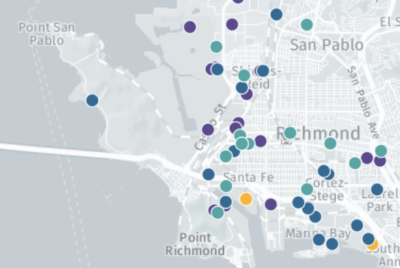

Image from: https://richmondconfidential.org/2017/10/28/richmonds-toxics-2/

**Using machine learning for air quality prediction is a field that is developing quickly. Studies are usually designed to predict air quality at one location (typically a sensitive receptor such as a school or park) based on air quality measured at several surrounding monitors and meteorological data. This project will tackle the inverse problem, where emissions in the area are predicted using the concentrations measured at several monitors. If successful, a model can take the place of methods such as chemical transport models (time intensive, difficult to set up and run).**

**The proposed model will use emissions, meteorological, and air quality monitoring data over two years from 2016 to 2017. The model will extract out extreme events (e.g. top 10% of measured concentrations at each monitor) and predict emissions for those events. Due to confidentiality issues the pollutant of interest and emission sources will be masked, but insights and physical interpretations will still be explained.**

**Research questions include:**

- **Can a reasonably good emissions prediction model be built using the available datasets?**
- **What are the most important features in predicting emissions?**
- **Knowing nothing about the processes that emit the pollutant, can we make a prediction on what kinds of sources contribute to the emissions based on observations from other variables in the dataset?**
- **How can the model be improved? What additional data would be most helpful to add?**

# Data Description

### Emissions Data

- **Aggregated hourly emissions data from 20 different sources in Richmond will be used as features in the model. These 20 sources are the biggest emitters of the pollutant of interest for this model. This data is not available publicly.**
- **This is the target variable for prediction.**

### Monitoring Data

- **Hazardous air pollutant and criteria air pollutant concentrations and meteorological data from three fenceline monitors, available on Richmond's fenceline monitoring website: https://www.richmondairmonitoring.org/measurements.html**
- **Hazardous air pollutant and criteria air pollutant concentrations and meteorological data from four community air monitors, available on Richmond's community air monitoring website: https://opendata.ci.richmond.ca.us/stories/s/Air-Monitoring/jqp5-q3g4/**
- **EPA/Bay Area AQMD air quality monitoring data for four stations in Richmond: https://aqs.epa.gov/aqsweb/documents/data_api.html**
- **Measured air pollutants in the monitoring datasets include the following:**
- **NH3: emitted from nitrogen products (fertilizer), biogenic sources**
- **H2S: emitted from sulfur products, landfills**
- **BC: emitted from diesel combustion**
- **PM25: various sources, most common is wind blown dust**
- **SO2: emitted from combustion of sulfur impurities in products, such as coal or petroleum**

### Meteorological Data

**The monitoring data has temperature, wind speed/direction, and humidity at each station, but extra data sources are needed to gather precipitation, solar insolation, and ceiling height (height of the lowest clouds):**

- **Precipitation from City of Richmond: http://cdec.water.ca.gov/dynamicapp/QueryF?s=RHL&d=31-Dec-2017+23:39&span=8760hours**
- **Solar radiation from NREL: https://maps.nrel.gov/nsrdb-viewer**
- **Ceiling height from NCDC, Oakland Airport station: https://www7.ncdc.noaa.gov/CDO/cdopoemain.cmd?datasetabbv=DS3505**

### Dispersion Modeling Data

**An important factor in air quality modeling is terrain and the location of emissions sources and monitoring stations relative to each other, which is not accounted for in any of the three data sources listed above. To account for this, outputs from a quick model run of EPA's AERMOD dispersion model is used as an input.**

```python
import pandas as pd
import numpy as np
import math
import datetime as dt
import matplotlib.pyplot as plt
import seaborn as sns
import urllib.request
import json
from scipy.stats import boxcox
from sklearn.model_selection import train_test_split
from sklearn.preprocessing import StandardScaler
from sklearn.linear_model import RidgeCV
from sklearn.decomposition import PCA
from sklearn.ensemble import RandomForestRegressor
from xgboost import XGBRegressor
from keras.models import Model, Sequential
from keras.layers import Input, Dense, Activation, Dropout, SimpleRNN, LSTM, Reshape, Lambda
from keras.optimizers import Adam
from keras.regularizers import l2
from keras import backend as K
```

# Data Retrieval, Cleaning, and EDA

### Emissions Data

**Aggregated emissions data for all sources within the area is provided by the local air agency. This data is not available publicly. We'll call the pollutant that this emission rate corresponds to pollutant "X".**

```python
emis = pd.read_excel("data/houremis.xlsx")
```

```python
emis.tail()
```

|  | year | month | day | hour | emisrate |
| --- | --- | --- | --- | --- | --- |
| 17539 | 2017 | 12 | 31 | 20 | 2.36 |
| 17540 | 2017 | 12 | 31 | 21 | 2.32 |
| 17541 | 2017 | 12 | 31 | 22 | 2.22 |
| 17542 | 2017 | 12 | 31 | 23 | 2.14 |
| 17543 | 2017 | 12 | 31 | 24 | 2.16 |

**Subtract 1 from 'hour' to match other dataframes that will be loaded in later:**

```python
emis['hour'] = emis['hour']-1
```

```python
emis.describe()
```

|  | year | month | day | hour | emisrate |
| --- | --- | --- | --- | --- | --- |
| count | 17544.000000 | 17544.000000 | 17544.000000 | 17544.000000 | 17544.000000 |
| mean | 2016.499316 | 6.519836 | 15.738714 | 11.500000 | 1.609733 |
| std | 0.500014 | 3.449649 | 8.804172 | 6.922384 | 1.027877 |
| min | 2016.000000 | 1.000000 | 1.000000 | 0.000000 | 0.000000 |
| 25% | 2016.000000 | 4.000000 | 8.000000 | 5.750000 | 0.774750 |
| 50% | 2016.000000 | 7.000000 | 16.000000 | 11.500000 | 1.660000 |
| 75% | 2017.000000 | 10.000000 | 23.000000 | 17.250000 | 2.260000 |
| max | 2017.000000 | 12.000000 | 31.000000 | 23.000000 | 22.100000 |

**This file contains 17544 hours (8760 in 2017, 8784 hours in 2016 since it was a leap year) worth of aggregated emissions data. Visualizing a timeseries of hourly emission rates of "X" below:**

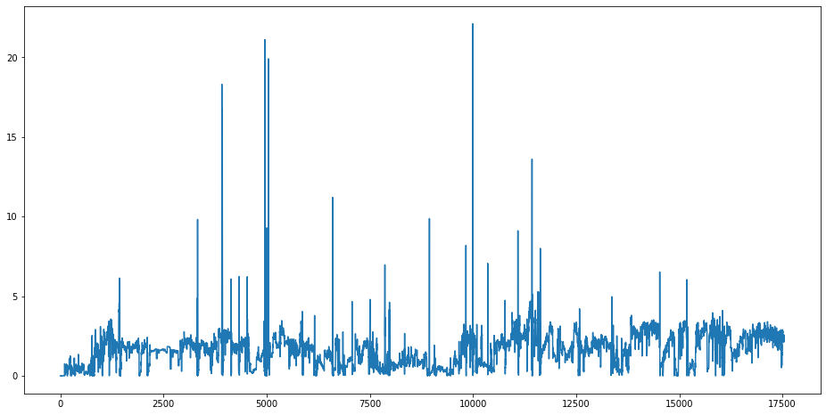

```python
plt.figure(figsize=(16,8))
plt.plot(emis.emisrate)
```

**We can see that emissions are very sporadic, with some extreme events scattered randomly throughout. This is common in many air quality analyses, and is characteristic of equipment malfunctions or sudden throughput increases amid routine service.**

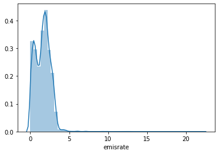

```python
sns.distplot(emis.emisrate)
```

```python
emis.emisrate.skew()
```

```
2.656924870568949
```

**The distribution appears to be bimodal and positively skewed, so keep in mind that this may need some sort of transform to a normal distribution as the target variable before training the model. We will end up filtering the dataset for the top 10% measurements of SO2 concentrations at each monitor, so the filtered dataset's distribution may change.**

### Dispersion Modeling Data

**Dispersion modeling is commonly used in air quality analysis to determine the fate and transport of pollutants. It takes the locations of sources and receptors, meteorology, and terrain of the area into account. The number resulting from the dispersion model output represents the "strength" attributed to each source at each receptor (in this case, each monitor). A higher number indicates that the meteorology and terrain are favorable in transporting pollutants from a given source to a specific monitor.**

**US EPA's AERMOD dispersion model was used to produce these outputs. Inputs to the model included the locations of each source, locations of each monitor, and default EPA meteorlogy and terrain data. The purpose of including these outputs in the machine learning model is to feed the model features that take terrain and transport into account.**

**Model outputs were outputted and saved as a pickle file:**

```python
df_aermod = pd.read_pickle("data/aermod_out.pkl")
```

```python
pd.set_option('display.max_columns',500)
df_aermod.head()
```

|  | DATE | S1_UV1_1 | S1_UV1_10 | S1_UV1_11 | S1_UV1_12 | S1_UV1_13 | S1_UV1_14 | S1_UV1_15 | S1_UV1_16 | S1_UV1_17 | S1_UV1_18 | S1_UV1_19 | S1_UV1_2 | S1_UV1_20 | S1_UV1_21 | S1_UV1_3 | S1_UV1_4 | S1_UV1_5 | S1_UV1_6 | S1_UV1_7 | S1_UV1_8 | S1_UV1_9 | S1_CMS1 | S1_GLM1 | S1_GLM2 | S1_GLM3 | S1_CMS2 | S1_UV2_1 | S1_UV2_10 | … |
| --- | --- | --- | --- | --- | --- | --- | --- | --- | --- | --- | --- | --- | --- | --- | --- | --- | --- | --- | --- | --- | --- | --- | --- | --- | --- | --- | --- | --- | --- | --- |
| 0 | 16010101 | 0.0 | 0.0 | 0.0 | 0.0 | 0.0 | 0.0 | 0.0 | 0.0 | 0.0 | 0.0 | 0.0 | 0.0 | 0.0 | 0.0 | 0.0 | 0.0 | 0.0 | 0.0 | 0.0 | 0.0 | 0.0 | 0.0 | 0.0 | 0.0 | 0.0 | 0.0 | 0.0 | 0.0 | … |
| 1 | 16010102 | 0.0 | 0.0 | 0.0 | 0.0 | 0.0 | 0.0 | 0.0 | 0.0 | 0.0 | 0.0 | 0.0 | 0.0 | 0.0 | 0.0 | 0.0 | 0.0 | 0.0 | 0.0 | 0.0 | 0.0 | 0.0 | 0.0 | 0.0 | 0.0 | 0.0 | 0.0 | 0.0 | 0.0 | … |
| 2 | 16010103 | 0.0 | 0.0 | 0.0 | 0.0 | 0.0 | 0.0 | 0.0 | 0.0 | 0.0 | 0.0 | 0.0 | 0.0 | 0.0 | 0.0 | 0.0 | 0.0 | 0.0 | 0.0 | 0.0 | 0.0 | 0.0 | 0.0 | 0.0 | 0.0 | 0.0 | 0.0 | 0.0 | 0.0 | … |
| 3 | 16010104 | 0.0 | 0.0 | 0.0 | 0.0 | 0.0 | 0.0 | 0.0 | 0.0 | 0.0 | 0.0 | 0.0 | 0.0 | 0.0 | 0.0 | 0.0 | 0.0 | 0.0 | 0.0 | 0.0 | 0.0 | 0.0 | 0.0 | 0.0 | 0.0 | 0.0 | 0.0 | 0.0 | 0.0 | … |
| 4 | 16010105 | 0.0 | 0.0 | 0.0 | 0.0 | 0.0 | 0.0 | 0.0 | 0.0 | 0.0 | 0.0 | 0.0 | 0.0 | 0.0 | 0.0 | 0.0 | 0.0 | 0.0 | 0.0 | 0.0 | 0.0 | 0.0 | 0.0 | 0.0 | 0.0 | 0.0 | 0.0 | 0.0 | 0.0 | … |

**The contents of this dataframe are difficult to decipher, so I'll explain below:**

- **Aside from the DATE column, each column represents the hourly source-receptor "strength". The source is represented by the first substring ahead of the first underscore, and the receptor (i.e., monitor) code is represented by the second substring.**
- **There are 6 different sources, numbered from S1 through S6.**
- **Of the receptors (monitors), there are two UV fencelines represented by 31 receptors (21 receptors in fenceline UV1, 10 receptors in fenceline UV2), three community monitoring stations (CMS1 through CMS3), and three ground level monitors (GLM1 through GLM3).**
- **The dataframe lists a source-receptor "strength" between each source and monitor.**
- **Source-receptor strengths of zero or close to zero indicate that transport of pollutants from the given source to the given monitor is not favorable during that hour, i.e. winds are blowing in the opposite direction or terrain obstructs the flow.**

**Basic numerical EDA for each column, sorted in descending order by the average values:**

```python
pd.set_option('display.max_rows',500)
df_aermod.describe().transpose().sort_values('mean',ascending=False)
```

|  | count | mean | std | min | 25% | 50% | 75% | max |
| --- | --- | --- | --- | --- | --- | --- | --- | --- |
| S5_UV1_13 | 17544.0 | 0.563802 | 2.120977 | 0.0 | 1.294033e-02 | 0.022011 | 0.047140 | 24.434658 |
| S5_UV1_14 | 17544.0 | 0.561425 | 2.061551 | 0.0 | 1.319132e-02 | 0.022587 | 0.048147 | 29.582517 |
| S5_UV1_12 | 17544.0 | 0.561064 | 2.144524 | 0.0 | 1.291998e-02 | 0.021897 | 0.046916 | 24.565093 |
| S5_UV1_15 | 17544.0 | 0.544976 | 1.941020 | 0.0 | 1.318345e-02 | 0.022746 | 0.048084 | 23.138530 |
| S5_UV1_1 | 17544.0 | 0.532680 | 2.258138 | 0.0 | 1.264632e-02 | 0.021298 | 0.045374 | 29.275908 |
| S5_UV1_16 | 17544.0 | 0.514346 | 1.855337 | 0.0 | 1.284434e-02 | 0.022359 | 0.047283 | 23.476306 |
| S5_UV1_17 | 17544.0 | 0.457120 | 1.678681 | 0.0 | 1.300035e-02 | 0.022552 | 0.047403 | 22.162431 |
| S1_UV2_4 | 17544.0 | 0.451286 | 5.761724 | 0.0 | 6.593632e-07 | 0.003853 | 0.101911 | 632.862844 |
| S1_UV2_5 | 17544.0 | 0.448699 | 4.937539 | 0.0 | 2.853723e-07 | 0.003978 | 0.104211 | 505.572359 |
| S1_UV2_3 | 17544.0 | 0.444511 | 5.957744 | 0.0 | 1.151492e-06 | 0.003795 | 0.095621 | 660.233144 |
| S1_UV2_6 | 17544.0 | 0.439630 | 3.916071 | 0.0 | 1.469500e-07 | 0.003911 | 0.102295 | 324.538962 |
| S1_UV2_7 | 17544.0 | 0.437151 | 3.308925 | 0.0 | 8.027374e-08 | 0.003896 | 0.097069 | 160.864734 |
| S1_UV2_2 | 17544.0 | 0.432055 | 5.641023 | 0.0 | 1.791933e-06 | 0.003683 | 0.090973 | 606.990128 |
| S1_UV2_8 | 17544.0 | 0.426299 | 3.147081 | 0.0 | 3.923125e-08 | 0.003797 | 0.087249 | 139.714560 |
| S1_UV2_9 | 17544.0 | 0.423412 | 3.502668 | 0.0 | 1.870246e-08 | 0.003685 | 0.071566 | 215.607364 |
| S1_UV2_10 | 17544.0 | 0.421094 | 3.957550 | 0.0 | 1.156404e-08 | 0.003609 | 0.063640 | 287.901102 |
| S1_UV2_1 | 17544.0 | 0.414024 | 5.065151 | 0.0 | 2.850321e-06 | 0.003488 | 0.080909 | 504.469649 |
| S1_GLM2 | 17544.0 | 0.406113 | 4.331013 | 0.0 | 4.566860e-06 | 0.003248 | 0.063895 | 266.169804 |
| S5_UV1_18 | 17544.0 | 0.381735 | 1.414193 | 0.0 | 1.273719e-02 | 0.022113 | 0.045470 | 21.026462 |
| S1_UV1_9 | 17544.0 | 0.376831 | 18.877916 | 0.0 | 1.067709e-13 | 0.000185 | 0.014403 | 1971.570248 |
| S1_UV1_8 | 17544.0 | 0.375764 | 17.100317 | 0.0 | 6.984788e-13 | 0.000539 | 0.014218 | 1575.096889 |
| S5_GLM3 | 17544.0 | 0.374288 | 1.557773 | 0.0 | 5.495663e-03 | 0.009092 | 0.021998 | 19.792379 |
| S5_UV1_11 | 17544.0 | 0.349732 | 1.130080 | 0.0 | 1.124574e-02 | 0.020336 | 0.042314 | 12.401929 |
| S5_UV1_10 | 17544.0 | 0.345785 | 1.145674 | 0.0 | 1.168998e-02 | 0.021024 | 0.042904 | 14.115434 |
| S5_UV1_3 | 17544.0 | 0.336967 | 1.116124 | 0.0 | 1.085936e-02 | 0.019711 | 0.041238 | 16.184923 |
| S1_UV1_1 | 17544.0 | 0.335077 | 12.648023 | 0.0 | 2.318894e-06 | 0.001498 | 0.004218 | 1023.761550 |
| S3_GLM1 | 17544.0 | 0.327265 | 7.314224 | 0.0 | 1.131209e-03 | 0.005571 | 0.016814 | 933.759575 |
| S5_UV1_19 | 17544.0 | 0.322984 | 1.239502 | 0.0 | 1.225493e-02 | 0.021244 | 0.043159 | 22.187970 |
| S1_UV1_12 | 17544.0 | 0.318069 | 11.785703 | 0.0 | 1.425073e-06 | 0.001575 | 0.004466 | 984.705913 |
| S1_UV1_13 | 17544.0 | 0.313760 | 11.571133 | 0.0 | 1.275204e-06 | 0.001591 | 0.004527 | 972.849900 |

[output cut: 192 more lines]

**There is a lot to look through here, but basic information you can infer from this includes:**

- **Average source-receptor strength is the highest between UV fenceline #1 and source #5. It's likely that these two are located very close to each other.**
- **Generally, the UV fenceline and GLM source-receptor strengths are higher than the CMS receptor strengths. This is because the CMS monitors are further away from the emissions sources.**

**Graphical EDA: define a function that will be used in this notebook to produce a Seaborn distplot for each feature:**

```python
def distplots(df, cols, ncol_plot=3):
    nrow_plot = int(np.ceil(len(cols)/ncol_plot))
    fig, ax = plt.subplots(nrow_plot, ncol_plot, figsize=(16,16/ncol_plot*nrow_plot))
    r = 0
    c = 0
    for col in cols:
        sns.distplot(df[col], ax=ax[r,c], kde=False)
        ax[r,c].set_title(col)
        c += 1
        if c == ncol_plot:
            c = 0
            r += 1
```

[figure not shown]

```python
distplots(df_aermod, [col for col in df_aermod.columns if col != "DATE"])
```

**These features are very skewed and will definitely need a Box-Cox transformation down the line. I will leave this data as is for now, and perform any transformations or additional analysis on the full input dataframe later.**

### Monitoring Data

**Unlike the emissions and dispersion modeling data, the monitoring data is still in a very raw state and will need significant processing. The monitoring data will come from 4 different sources:**

**First, let's load in and look at the community monitoring station (CMS) and UV fenceline (UV) data:**

```python
cms = pd.read_pickle("data/cms.pkl")
uv = pd.read_pickle("data/uv.pkl")
```

```python
cms.head()
```

|  | ACTUALDATE | YEAR | MONTH | DAY | HOUR | MINUTE | NH3_CMS1 | H2S_CMS1 | BC_CMS1 | PM25_CMS1 | WD_CMS1 | WS_CMS1 | HUM_CMS1 | TEMP_CMS1 | NH3_CMS2 | H2S_CMS2 | BC_CMS2 | PM25_CMS2 | WD_CMS2 | WS_CMS2 | HUM_CMS2 | TEMP_CMS2 | NH3_CMS3 | H2S_CMS3 | BC_CMS3 | PM25_CMS3 | WD_CMS3 | WS_CMS3 | HUM_CMS3 | … |
| --- | --- | --- | --- | --- | --- | --- | --- | --- | --- | --- | --- | --- | --- | --- | --- | --- | --- | --- | --- | --- | --- | --- | --- | --- | --- | --- | --- | --- | --- | --- |
| 0 | 2016-01-01 00:00:00 | 2016 | 1.0 | 1 | 0.0 | 0 | 4.62 | 2.11 | 4.157 | 41.0 | 47.0 | 11.0 | 74.0 | 36.0 | 7.84 | 1.0 | 1.963 | 18.0 | 49.0 | 2.0 | 74.0 | 36.0 | 3.42 | 4.14 | 4.339 | 26.0 | 186.0 | 0.0 | 75.0 | … |
| 1 | 2016-01-01 00:05:00 | 2016 | 1.0 | 1 | 0.0 | 5 | 4.82 | 2.00 | 4.722 | 41.0 | 27.0 | 9.0 | 75.0 | 36.0 | 8.16 | 1.0 | 2.398 | 18.0 | 48.0 | 2.0 | 75.0 | 36.0 | 4.08 | 1.00 | 4.069 | 26.0 | 149.0 | 0.0 | 75.0 | … |
| 2 | 2016-01-01 00:10:00 | 2016 | 1.0 | 1 | 0.0 | 10 | 5.12 | 2.00 | 5.897 | 41.0 | 346.0 | 9.0 | 75.0 | 36.0 | 8.78 | 1.0 | 2.869 | 18.0 | 56.0 | 2.0 | 76.0 | 36.0 | 3.68 | 1.00 | 4.132 | 26.0 | 106.0 | 0.0 | 75.0 | … |
| 3 | 2016-01-01 00:15:00 | 2016 | 1.0 | 1 | 0.0 | 15 | 4.98 | 1.00 | 11.113 | 41.0 | 342.0 | 10.0 | 75.0 | 36.0 | 9.75 | 1.0 | 9.946 | 18.0 | 14.0 | 2.0 | 77.0 | 35.0 | 3.48 | 1.00 | 4.012 | 26.0 | 249.0 | 1.0 | 76.0 | … |
| 4 | 2016-01-01 00:20:00 | 2016 | 1.0 | 1 | 0.0 | 20 | 5.08 | 1.00 | 9.306 | 41.0 | 317.0 | 11.0 | 75.0 | 36.0 | 9.89 | 1.0 | 3.489 | 18.0 | 352.0 | 2.0 | 77.0 | 35.0 | 3.38 | 1.00 | 3.989 | 26.0 | 223.0 | 1.0 | 77.0 | … |

```python
uv.head()
```

|  | ACTUALDATE | YEAR | MONTH | DAY | HOUR | MINUTE | SO2_UV1 | WD_UV1 | WS_UV1 | TEMP_UV1 | HUM_UV1 | SO2_UV2 | WD_UV2 | WS_UV2 | TEMP_UV2 | HUM_UV2 | SO2_UV3 | WD_UV3 | WS_UV3 | TEMP_UV3 | HUM_UV3 |
| --- | --- | --- | --- | --- | --- | --- | --- | --- | --- | --- | --- | --- | --- | --- | --- | --- | --- | --- | --- | --- | --- |
| 0 | 2016-01-01 00:00:00 | 2016 | 1.0 | 1 | 0.0 | 0 | NaN | 19.0 | 4.0 | 40.0 | 70.0 | NaN | 69.0 | 4.0 | 36.0 | 74.0 | NaN | 19.0 | 4.0 | 40.0 | 70.0 |
| 1 | 2016-01-01 00:05:00 | 2016 | 1.0 | 1 | 0.0 | 5 | NaN | 17.0 | 4.0 | 40.0 | 69.0 | NaN | 67.0 | 4.0 | 36.0 | 72.0 | NaN | 17.0 | 4.0 | 40.0 | 69.0 |
| 2 | 2016-01-01 00:10:00 | 2016 | 1.0 | 1 | 0.0 | 10 | NaN | 67.0 | 4.0 | 39.0 | 69.0 | NaN | 79.0 | 5.0 | 37.0 | 71.0 | NaN | 67.0 | 4.0 | 39.0 | 69.0 |
| 3 | 2016-01-01 00:15:00 | 2016 | 1.0 | 1 | 0.0 | 15 | NaN | 75.0 | 3.0 | 38.0 | 71.0 | NaN | 80.0 | 4.0 | 36.0 | 72.0 | NaN | 75.0 | 3.0 | 38.0 | 71.0 |
| 4 | 2016-01-01 00:20:00 | 2016 | 1.0 | 1 | 0.0 | 20 | NaN | 0.0 | 3.0 | 37.0 | 73.0 | NaN | 47.0 | 2.0 | 36.0 | 74.0 | NaN | 0.0 | 3.0 | 37.0 | 73.0 |

**Merge on common columns to get all features into one dataframe:**

```python
cms_uv = pd.merge(cms,uv,on=['ACTUALDATE','YEAR','MONTH','DAY','HOUR','MINUTE'],how='outer')
cms_uv.head()
```

|  | ACTUALDATE | YEAR | MONTH | DAY | HOUR | MINUTE | NH3_CMS1 | H2S_CMS1 | BC_CMS1 | PM25_CMS1 | WD_CMS1 | WS_CMS1 | HUM_CMS1 | TEMP_CMS1 | NH3_CMS2 | H2S_CMS2 | BC_CMS2 | PM25_CMS2 | WD_CMS2 | WS_CMS2 | HUM_CMS2 | TEMP_CMS2 | NH3_CMS3 | H2S_CMS3 | BC_CMS3 | PM25_CMS3 | WD_CMS3 | WS_CMS3 | HUM_CMS3 | … |
| --- | --- | --- | --- | --- | --- | --- | --- | --- | --- | --- | --- | --- | --- | --- | --- | --- | --- | --- | --- | --- | --- | --- | --- | --- | --- | --- | --- | --- | --- | --- |
| 0 | 2016-01-01 00:00:00 | 2016 | 1.0 | 1 | 0.0 | 0 | 4.62 | 2.11 | 4.157 | 41.0 | 47.0 | 11.0 | 74.0 | 36.0 | 7.84 | 1.0 | 1.963 | 18.0 | 49.0 | 2.0 | 74.0 | 36.0 | 3.42 | 4.14 | 4.339 | 26.0 | 186.0 | 0.0 | 75.0 | … |
| 1 | 2016-01-01 00:05:00 | 2016 | 1.0 | 1 | 0.0 | 5 | 4.82 | 2.00 | 4.722 | 41.0 | 27.0 | 9.0 | 75.0 | 36.0 | 8.16 | 1.0 | 2.398 | 18.0 | 48.0 | 2.0 | 75.0 | 36.0 | 4.08 | 1.00 | 4.069 | 26.0 | 149.0 | 0.0 | 75.0 | … |
| 2 | 2016-01-01 00:10:00 | 2016 | 1.0 | 1 | 0.0 | 10 | 5.12 | 2.00 | 5.897 | 41.0 | 346.0 | 9.0 | 75.0 | 36.0 | 8.78 | 1.0 | 2.869 | 18.0 | 56.0 | 2.0 | 76.0 | 36.0 | 3.68 | 1.00 | 4.132 | 26.0 | 106.0 | 0.0 | 75.0 | … |
| 3 | 2016-01-01 00:15:00 | 2016 | 1.0 | 1 | 0.0 | 15 | 4.98 | 1.00 | 11.113 | 41.0 | 342.0 | 10.0 | 75.0 | 36.0 | 9.75 | 1.0 | 9.946 | 18.0 | 14.0 | 2.0 | 77.0 | 35.0 | 3.48 | 1.00 | 4.012 | 26.0 | 249.0 | 1.0 | 76.0 | … |
| 4 | 2016-01-01 00:20:00 | 2016 | 1.0 | 1 | 0.0 | 20 | 5.08 | 1.00 | 9.306 | 41.0 | 317.0 | 11.0 | 75.0 | 36.0 | 9.89 | 1.0 | 3.489 | 18.0 | 352.0 | 2.0 | 77.0 | 35.0 | 3.38 | 1.00 | 3.989 | 26.0 | 223.0 | 1.0 | 77.0 | … |

**The format for the name of each column is described below:**

- **The first substring before the underscore is what is being measured, the second substring is the name of the monitor.**
- **NH3, H2S, BC, PM25, and SO2 are all pollutant concentration measurements. Emissions of each of these pollutants originate from different sources, and all five pollutants are intended to be a "proxy" for the activity at each measurement. For example, an interval with high BC concentrations may indicate that a heavy-duty truck had just passed on the monitor. Note that the emission rate that the model will predict is not one of these five pollutants. In other words, we are attempting to predict an emission rate for a pollutant that is not in the input dataset.**
- **WD = wind direction, WS = wind speec, HUM = humidity, TEMP = temperature. Meteorological variables are important in considering the atmospheric conditions and transport.**

**More on the pollutants in this dataset:**

- **NH3: emitted from chemical processes involving nitrogen, such as oil refining, fertilizer production, or landfills.**
- **H2S: emitted from chemical processes involving sulfur, such as sulfur production.**
- **BC: emitted from combustion sources, mostly heavy-duty diesel trucks. Typically higher closer to roadways.**
- **PM25: emitted from combustion or fugitive dust sources, typically higher closer to roadways.**
- **SO2: emitted from combustion of sulfur products, such as from oil refining or mobile sources.**

**Basic numerical EDA:**

```python
cms_uv.describe().transpose()
```

|  | count | mean | std | min | 25% | 50% | 75% | max |
| --- | --- | --- | --- | --- | --- | --- | --- | --- |
| YEAR | 210250.0 | 2016.498759 | 0.500000 | 2016.000 | 2016.000 | 2016.000 | 2017.000 | 2017.000 |
| MONTH | 210250.0 | 6.521165 | 3.450348 | 1.000 | 4.000 | 7.000 | 10.000 | 12.000 |
| DAY | 210250.0 | 15.740894 | 8.805173 | 1.000 | 8.000 | 16.000 | 23.000 | 31.000 |
| HOUR | 210250.0 | 11.499905 | 6.917365 | 0.000 | 6.000 | 12.000 | 17.000 | 23.000 |
| MINUTE | 210250.0 | 27.502459 | 17.261226 | 0.000 | 11.000 | 30.000 | 45.000 | 58.000 |
| NH3_CMS1 | 199668.0 | 6.244535 | 5.625910 | 1.000 | 2.900 | 4.700 | 7.730 | 263.600 |
| H2S_CMS1 | 195311.0 | 1.339575 | 0.694018 | 1.000 | 1.000 | 1.000 | 1.000 | 35.330 |
| BC_CMS1 | 206758.0 | 0.284829 | 0.338313 | 0.025 | 0.087 | 0.180 | 0.368 | 17.008 |
| PM25_CMS1 | 185839.0 | 8.226077 | 8.409359 | 3.000 | 3.000 | 7.000 | 10.000 | 261.000 |
| WD_CMS1 | 208064.0 | 200.761564 | 81.991829 | 0.000 | 155.000 | 173.000 | 260.000 | 360.000 |
| WS_CMS1 | 165800.0 | 7.495856 | 4.061447 | -1.000 | 5.000 | 7.000 | 10.000 | 97.000 |
| HUM_CMS1 | 208444.0 | 73.853659 | 15.835564 | 11.000 | 66.000 | 78.000 | 86.000 | 97.000 |
| TEMP_CMS1 | 208442.0 | 58.633087 | 8.179001 | 31.000 | 54.000 | 58.000 | 63.000 | 120.000 |
| NH3_CMS2 | 200123.0 | 5.361829 | 4.903215 | 1.000 | 2.230 | 3.920 | 6.930 | 165.710 |
| H2S_CMS2 | 202061.0 | 1.148821 | 0.685995 | 1.000 | 1.000 | 1.000 | 1.000 | 35.330 |
| BC_CMS2 | 206396.0 | 0.357705 | 0.507341 | 0.025 | 0.102 | 0.216 | 0.441 | 30.791 |
| PM25_CMS2 | 185240.0 | 7.993614 | 8.304395 | 3.000 | 3.000 | 7.000 | 10.000 | 261.000 |
| WD_CMS2 | 175480.0 | 198.056394 | 90.488694 | 0.000 | 151.000 | 176.000 | 274.000 | 360.000 |
| WS_CMS2 | 200325.0 | 5.993351 | 3.586427 | 0.000 | 3.000 | 6.000 | 8.000 | 34.000 |
| HUM_CMS2 | 207927.0 | 73.867352 | 15.909865 | 8.000 | 66.000 | 77.000 | 86.000 | 98.000 |
| TEMP_CMS2 | 207840.0 | 58.169347 | 7.742099 | 17.000 | 54.000 | 58.000 | 62.000 | 109.000 |
| NH3_CMS3 | 205990.0 | 2.940744 | 4.305102 | 1.000 | 1.000 | 1.000 | 3.720 | 301.920 |
| H2S_CMS3 | 206546.0 | 1.258524 | 0.930399 | 1.000 | 1.000 | 1.000 | 1.000 | 63.560 |
| BC_CMS3 | 203851.0 | 0.403638 | 0.617983 | 0.025 | 0.068 | 0.187 | 0.498 | 49.931 |
| PM25_CMS3 | 206800.0 | 7.860701 | 8.182456 | 3.000 | 3.000 | 6.000 | 10.000 | 279.000 |
| WD_CMS3 | 207555.0 | 206.038587 | 83.961712 | 0.000 | 143.000 | 215.000 | 268.000 | 360.000 |
| WS_CMS3 | 207556.0 | 3.134821 | 2.156191 | 0.000 | 1.000 | 3.000 | 4.000 | 17.000 |
| HUM_CMS3 | 207556.0 | 72.744435 | 15.352141 | 8.000 | 65.000 | 76.000 | 85.000 | 95.000 |
| TEMP_CMS3 | 207556.0 | 58.412669 | 7.620023 | 32.000 | 54.000 | 58.000 | 62.000 | 106.000 |
| SO2_UV1 | 6115.0 | 14.536193 | 17.556587 | 5.000 | 6.460 | 9.100 | 14.965 | 278.240 |
| WD_UV1 | 209309.0 | 146.842768 | 141.456358 | -999.000 | 70.000 | 155.000 | 205.000 | 359.000 |
| WS_UV1 | 209309.0 | -0.199724 | 89.383480 | -999.000 | 5.000 | 7.000 | 10.000 | 38.000 |
| TEMP_UV1 | 209309.0 | 49.999360 | 94.091797 | -999.000 | 54.000 | 58.000 | 62.000 | 106.000 |
| HUM_UV1 | 209309.0 | 64.236942 | 96.349324 | -999.000 | 64.000 | 76.000 | 85.000 | 98.000 |
| SO2_UV2 | 14109.0 | 11.621104 | 16.587778 | 5.000 | 6.480 | 8.860 | 12.980 | 609.100 |
| WD_UV2 | 208400.0 | 183.058109 | 130.411257 | -999.000 | 152.000 | 190.000 | 230.000 | 359.000 |
| WS_UV2 | 208400.0 | 1.392438 | 81.184123 | -999.000 | 5.000 | 8.000 | 10.000 | 34.000 |
| TEMP_UV2 | 208400.0 | 51.258354 | 85.517906 | -999.000 | 53.000 | 57.000 | 63.000 | 108.000 |
| HUM_UV2 | 208400.0 | 65.206560 | 87.734796 | -999.000 | 63.000 | 76.000 | 85.000 | 97.000 |
| SO2_UV3 | 10689.0 | 73.130179 | 131.777522 | 5.000 | 8.770 | 21.200 | 74.400 | 998.350 |
| WD_UV3 | 209040.0 | 146.845202 | 141.503787 | -999.000 | 70.000 | 155.000 | 205.000 | 359.000 |
| WS_UV3 | 209040.0 | -0.208989 | 89.440540 | -999.000 | 5.000 | 7.000 | 10.000 | 38.000 |
| TEMP_UV3 | 209040.0 | 49.979439 | 94.150069 | -999.000 | 54.000 | 58.000 | 62.000 | 106.000 |
| HUM_UV3 | 209040.0 | 64.239729 | 96.408192 | -999.000 | 64.000 | 76.000 | 85.000 | 98.000 |

**For accounting purposes later on, replace all -999 with NaN. Values of -999 indicate missing data in this dataset.**

```python
cms_uv = cms_uv.replace(-999, np.nan)
```

**Transform wind speed and direction into x and y components, with 0 degrees as north to south. With this orientation, wind speeds in the x- and y-directions need to be multiplied by -1.**

```python
stations = ['CMS1','CMS2','CMS3','UV1','UV2','UV3']
for station in stations:
    cms_uv['WS_X_'+station] = cms_uv['WS_'+station]*np.sin(np.pi/180*cms_uv['WD_'+station])*-1
    cms_uv['WS_Y_'+station] = cms_uv['WS_'+station]*np.cos(np.pi/180*cms_uv['WD_'+station])*-1
```

**Get rid of the initial WS and WD columns, since all of the information is now in the WS_X and WS_Y columns:**

```python
cms_uv = cms_uv.drop(columns=['WD_'+x for x in stations])
cms_uv = cms_uv.drop(columns=['WS_'+x for x in stations])
```

**Since all 6 stations are in the vicinity of each other, temperature and humidity will essentially be the same across all stations. Aggregate the temperature and RH features into one (average across all 6 stations) and drop the original columns:**

```python
temp_cols = ['TEMP_'+x for x in stations]
rh_cols = ['HUM_'+x for x in stations]
cms_uv['TEMP'] = cms_uv[temp_cols].mean(axis=1)
cms_uv['RH'] = cms_uv[rh_cols].mean(axis=1)
cms_uv = cms_uv.drop(columns=temp_cols)
cms_uv = cms_uv.drop(columns=rh_cols)
```

```python
cms_uv.head()
```

|  | ACTUALDATE | YEAR | MONTH | DAY | HOUR | MINUTE | NH3_CMS1 | H2S_CMS1 | BC_CMS1 | PM25_CMS1 | NH3_CMS2 | H2S_CMS2 | BC_CMS2 | PM25_CMS2 | NH3_CMS3 | H2S_CMS3 | BC_CMS3 | PM25_CMS3 | SO2_UV1 | SO2_UV2 | SO2_UV3 | WS_X_CMS1 | WS_Y_CMS1 | WS_X_CMS2 | WS_Y_CMS2 | WS_X_CMS3 | WS_Y_CMS3 | WS_X_UV1 | WS_Y_UV1 | … |
| --- | --- | --- | --- | --- | --- | --- | --- | --- | --- | --- | --- | --- | --- | --- | --- | --- | --- | --- | --- | --- | --- | --- | --- | --- | --- | --- | --- | --- | --- | --- |
| 0 | 2016-01-01 00:00:00 | 2016 | 1.0 | 1 | 0.0 | 0 | 4.62 | 2.11 | 4.157 | 41.0 | 7.84 | 1.0 | 1.963 | 18.0 | 3.42 | 4.14 | 4.339 | 26.0 | NaN | NaN | NaN | -8.044891 | -7.501982 | -1.509419 | -1.312118 | 0.000000 | 0.000000 | -1.302273 | -3.782074 | … |
| 1 | 2016-01-01 00:05:00 | 2016 | 1.0 | 1 | 0.0 | 5 | 4.82 | 2.00 | 4.722 | 41.0 | 8.16 | 1.0 | 2.398 | 18.0 | 4.08 | 1.00 | 4.069 | 26.0 | NaN | NaN | NaN | -4.085914 | -8.019059 | -1.486290 | -1.338261 | -0.000000 | 0.000000 | -1.169487 | -3.825219 | … |
| 2 | 2016-01-01 00:10:00 | 2016 | 1.0 | 1 | 0.0 | 10 | 5.12 | 2.00 | 5.897 | 41.0 | 8.78 | 1.0 | 2.869 | 18.0 | 3.68 | 1.00 | 4.132 | 26.0 | NaN | NaN | NaN | 2.177297 | -8.732662 | -1.658075 | -1.118386 | -0.000000 | 0.000000 | -3.682019 | -1.562925 | … |
| 3 | 2016-01-01 00:15:00 | 2016 | 1.0 | 1 | 0.0 | 15 | 4.98 | 1.00 | 11.113 | 41.0 | 9.75 | 1.0 | 9.946 | 18.0 | 3.48 | 1.00 | 4.012 | 26.0 | NaN | NaN | NaN | 3.090170 | -9.510565 | -0.483844 | -1.940591 | 0.933580 | 0.358368 | -2.897777 | -0.776457 | … |
| 4 | 2016-01-01 00:20:00 | 2016 | 1.0 | 1 | 0.0 | 20 | 5.08 | 1.00 | 9.306 | 41.0 | 9.89 | 1.0 | 3.489 | 18.0 | 3.38 | 1.00 | 3.989 | 26.0 | NaN | NaN | NaN | 7.501982 | -8.044891 | 0.278346 | -1.980536 | 0.681998 | 0.731354 | -0.000000 | -3.000000 | … |

**Fill in missing values:**

- **Concentrations: fill with detection limits from air quality monitor's manufacturer. Missing values likely mean that the concentration in air was too low to detect.**
- **Temp and RH: interpolate between values. Assuming a linear form between temperature and humidity from one interval to the next is a typical assumption in filling in these values.**
- **WS: first check if corresponding station from other monitoring has data (i.e. if CMS1 is missing but UV1 has data, fill in with the CMS1 value). The number corresponding to each station indiciates the general region it is in (i.e. CMS1 and UV1 are near each other, CMS2 and UV2 are also near each other).**

```python
cms_uv.isnull().sum()
```

```
ACTUALDATE         0
YEAR               0
MONTH              0
DAY                0
HOUR               0
MINUTE             0
NH3_CMS1       10582
H2S_CMS1       14939
BC_CMS1         3492
PM25_CMS1      24411
NH3_CMS2       10127
H2S_CMS2        8189
BC_CMS2         3854
PM25_CMS2      25010
NH3_CMS3        4260
H2S_CMS3        3704
BC_CMS3         6399
PM25_CMS3       3450
SO2_UV1       204135
SO2_UV2       196141
SO2_UV3       199561
WS_X_CMS1      44829
WS_Y_CMS1      44829
WS_X_CMS2      42372
WS_Y_CMS2      42372
WS_X_CMS3       2695
WS_Y_CMS3       2695
WS_X_UV1        2601
WS_Y_UV1        2601
WS_X_UV2        3210
WS_Y_UV2        3210
WS_X_UV3        2870
WS_Y_UV3        2870
TEMP              77
RH                77
dtype: int64
```

**Fill in missing concentrations with detection limits:**

```python
dl = {'NH3':1, 'H2S':1, 'BC':0, 'PM25':3, 'SO2':5}
for pol in dl.keys():
    pol_cols = [col for col in cms_uv.columns if col.startswith(pol)]
    for col in pol_cols:
        cms_uv[col] = cms_uv[col].fillna(dl[pol])
```

**Interpolate to fill in missing temperatures and relative humidities:**

```python
cms_uv['TEMP'] = cms_uv['TEMP'].interpolate()
cms_uv['RH'] = cms_uv['RH'].interpolate()
```

**Grab corresponding values from other monitoring stations to fill in missing WS:**

```python
ws_cms_cols = [col for col in cms_uv.columns if (col.startswith('WS') and 'CMS' in col)]
ws_uv_cols = [col for col in cms_uv.columns if (col.startswith('WS') and 'UV' in col)]
for col in ws_cms_cols:
    cms_uv[col] = cms_uv[col].fillna(cms_uv[col.replace('CMS','UV')])
for col in ws_uv_cols:
    cms_uv[col] = cms_uv[col].fillna(cms_uv[col.replace('UV','CMS')])
```

```python
cms_uv.isnull().sum()
```

```
ACTUALDATE       0
YEAR             0
MONTH            0
DAY              0
HOUR             0
MINUTE           0
NH3_CMS1         0
H2S_CMS1         0
BC_CMS1          0
PM25_CMS1        0
NH3_CMS2         0
H2S_CMS2         0
BC_CMS2          0
PM25_CMS2        0
NH3_CMS3         0
H2S_CMS3         0
BC_CMS3          0
PM25_CMS3        0
SO2_UV1          0
SO2_UV2          0
SO2_UV3          0
WS_X_CMS1     1336
WS_Y_CMS1     1336
WS_X_CMS2      501
WS_Y_CMS2      501
WS_X_CMS3      287
WS_Y_CMS3      287
WS_X_UV1      1336
WS_Y_UV1      1336
WS_X_UV2       501
WS_Y_UV2       501
WS_X_UV3       287
WS_Y_UV3       287
TEMP             0
RH               0
dtype: int64
```

**There are still some NAs for wind speeds, this occurs where both matching stations have NAs at the same timestamp. Try interpolating here to get out the rest of the NAs:**

```python
ws_cols = [col for col in cms_uv.columns if col.startswith('WS')]
for col in ws_cols:
    cms_uv[col] = cms_uv[col].interpolate()
```

```python
cms_uv.isnull().sum()
```

```
ACTUALDATE    0
YEAR          0
MONTH         0
DAY           0
HOUR          0
MINUTE        0
NH3_CMS1      0
H2S_CMS1      0
BC_CMS1       0
PM25_CMS1     0
NH3_CMS2      0
H2S_CMS2      0
BC_CMS2       0
PM25_CMS2     0
NH3_CMS3      0
H2S_CMS3      0
BC_CMS3       0
PM25_CMS3     0
SO2_UV1       0
SO2_UV2       0
SO2_UV3       0
WS_X_CMS1     0
WS_Y_CMS1     0
WS_X_CMS2     0
WS_Y_CMS2     0
WS_X_CMS3     0
WS_Y_CMS3     0
WS_X_UV1      0
WS_Y_UV1      0
WS_X_UV2      0
WS_Y_UV2      0
WS_X_UV3      0
WS_Y_UV3      0
TEMP          0
RH            0
dtype: int64
```

**All good now, let's do some graphical EDA as a reality check:**

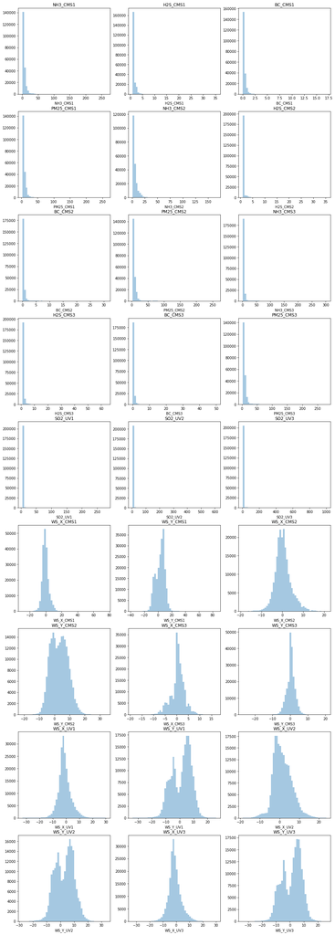

```python
plot_cols = [col for col in cms_uv.columns if ("CMS" in col or "UV" in col)]
distplots(cms_uv, plot_cols)
```

**Again some very skewed features which will need a transformation before model training. This makes sense for the data though - air quality measurements are usually positively skewed, since most measurements are at a "baseline" with some extreme events mixed in.**

**It's possible that the majority of readings are at the detection limit, or in other words, too low for the instruments to measure. Let's see what percentage of measurements are actually above the DL:**

```python
cms_pollutants = ['NH3','H2S','BC','PM25']
cms_stations = ['CMS1','CMS2','CMS3']
for pol in cms_pollutants:
    for st in cms_stations:
        col = pol+"_"+st
        pct_complete = cms_uv.loc[cms_uv[col] > dl[pol]].shape[0]/cms_uv.shape[0]
        print(col + ": " + str(round(pct_complete*100,1)) + "% complete")
```

```
NH3_CMS1: 82.2% complete
NH3_CMS2: 74.7% complete
NH3_CMS3: 39.9% complete
H2S_CMS1: 20.8% complete
H2S_CMS2: 6.8% complete
H2S_CMS3: 12.4% complete
BC_CMS1: 98.3% complete
BC_CMS2: 98.2% complete
BC_CMS3: 97.0% complete
PM25_CMS1: 56.9% complete
PM25_CMS2: 54.5% complete
PM25_CMS3: 58.3% complete
```

```python
uv_stations = ['UV1','UV2','UV3']
for st in uv_stations:
    col = "SO2_"+st
    pct_complete = cms_uv.loc[cms_uv[col] > dl['SO2']].shape[0]/cms_uv.shape[0]
    print(col + ": " + str(round(pct_complete*100,1)) + "% complete")
```

```
SO2_UV1: 2.9% complete
SO2_UV2: 6.7% complete
SO2_UV3: 5.1% complete
```

**It is important to note that the majority of data points for H2S and SO2 are reading at the detection limit. It is common in air quality analysis to select only the top X percent of events for model analysis, so this may not be an issue in the end, just something to keep in mind at the moment. We may end up selecting the top X percent of events from one of the SO2 UV stations (or with the low percentages we have, just the number of hits), and using that to train the model.**

**How do the pollutant concentration measurements correlate with each other? This may give a better idea of which pollutants are emitted together by the same process, and which are emitted by different processes.**

```python
pol_cols = []
for pol in cms_pollutants:
    for st in cms_stations:
        pol_cols.append(pol+"_"+st)
for st in uv_stations:
    pol_cols.append("SO2_"+st)
```

```python
pol_cols
```

```
['NH3_CMS1',
 'NH3_CMS2',
 'NH3_CMS3',
 'H2S_CMS1',
 'H2S_CMS2',
 'H2S_CMS3',
 'BC_CMS1',
 'BC_CMS2',
 'BC_CMS3',
 'PM25_CMS1',
 'PM25_CMS2',
 'PM25_CMS3',
 'SO2_UV1',
 'SO2_UV2',
 'SO2_UV3']
```

```python
def corr_matrix(df, num_cols, figsize=(15,15)):
    df_corrs = df[num_cols].corr().round(2)
    mask = np.zeros_like(df_corrs, dtype=np.bool)
    mask[np.triu_indices_from(mask)] = True
    f, ax = plt.subplots(figsize=figsize)
    sns.heatmap(df_corrs, annot=df_corrs, mask=mask, center=0, linewidths=.5, cbar=False)
```

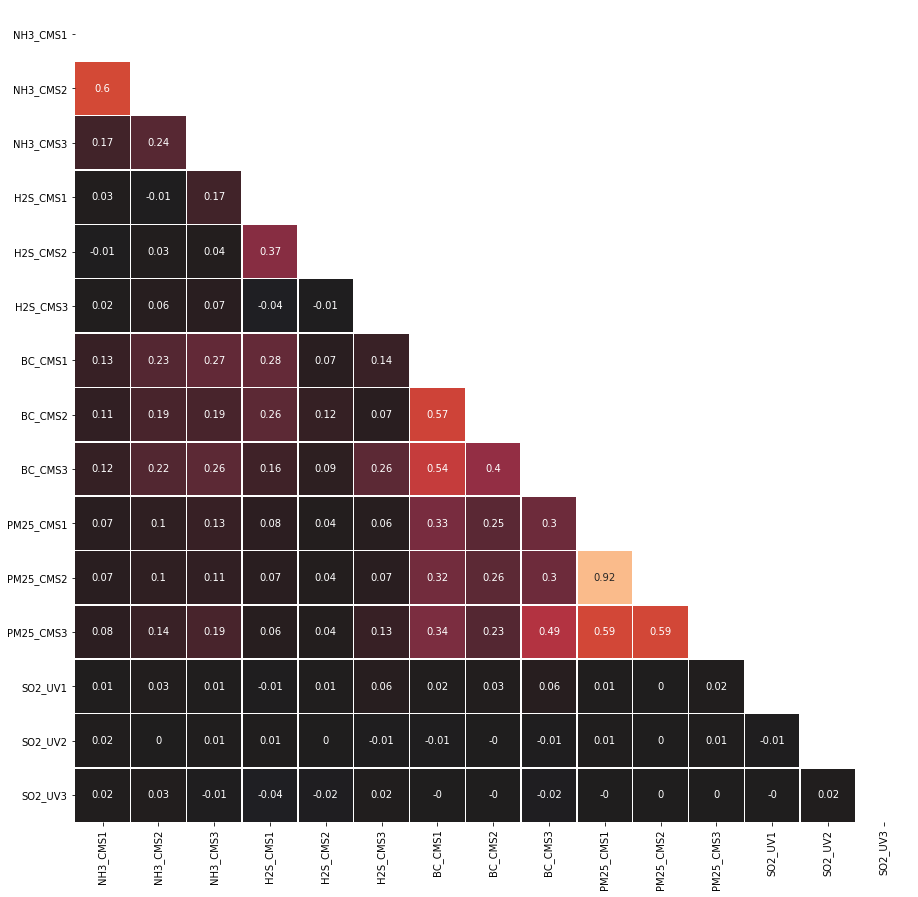

```python
corr_matrix(cms_uv, pol_cols)
```

**There are a few cases where the same pollutant measurements from different stations correlate well with each other (e.g. PM25_CMS1 with PM25_CMS2), but cross-pollutant correlations all look weak. The exception may be BC with PM25, which is not surprising since BC is a subset of PM25. This suggests that different processes are responsible for the emission of each pollutant.**

**One thing to watch out for in timeseries data is baseline drift, where the baseline measurement drifts upward or downwards over time, biasing the actual measurements. An easy way to detect this is to plot timeseries of pollutant measurements.**

**NH3:**

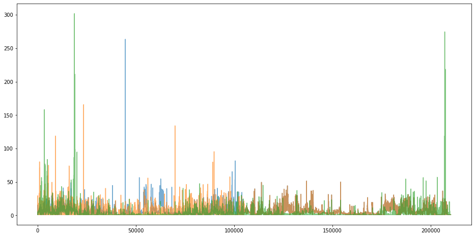

```python
plt.figure(figsize=(16,8))
plt.plot(cms_uv[['NH3_CMS1','NH3_CMS2','NH3_CMS3']], alpha=0.6)
```

**Baseline looks steady for NH3 measurements.**

**H2S:**

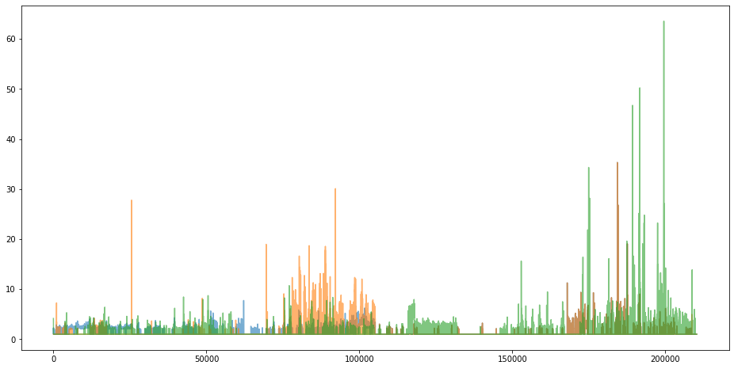

```python
plt.figure(figsize=(16,8))
plt.plot(cms_uv[['H2S_CMS1','H2S_CMS2','H2S_CMS3']], alpha=0.6)
```

**Baseline looks steady, and we see some interesting trends in H2S. It seems like events occur in batches rather than continuously at all three monitors, suggesting that some batch operation is responsible for H2S emissions in the area (likely seasonal chemical production of sulfur products, e.g. possibly gardening nutrients in the winter to prepare for crop season in the spring.**

**BC:**

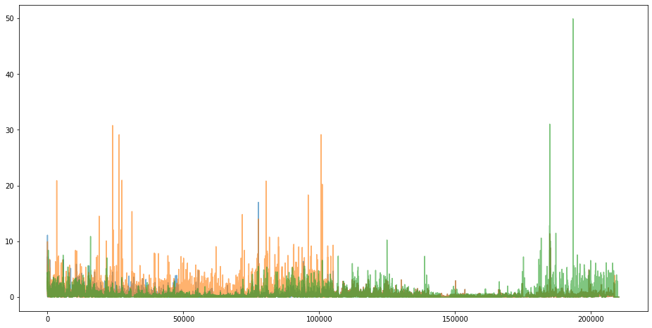

```python
plt.figure(figsize=(16,8))
plt.plot(cms_uv[['BC_CMS1','BC_CMS2','BC_CMS3']], alpha=0.6)
```

**Baseline looks fine for BC, and there is an interesting drop off in the middle of the dataset for the CMS2 station (orange line). This is because the trucking route to the nearby port was routed in the opposite direction at the end of 2016 due to protests from nearby residents.**

**PM25:**

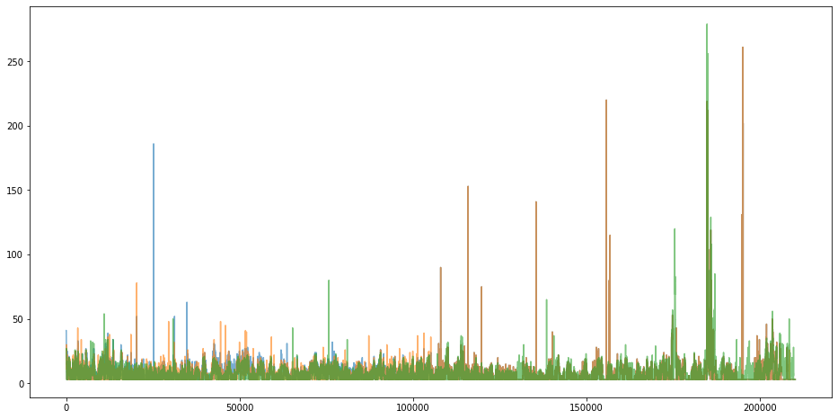

```python
plt.figure(figsize=(16,8))
plt.plot(cms_uv[['PM25_CMS1','PM25_CMS2','PM25_CMS3']], alpha=0.6)
```

**PM25 baseline looks fine, and there look to be a few extreme events scattered throughout the dataset.**

**SO2:**

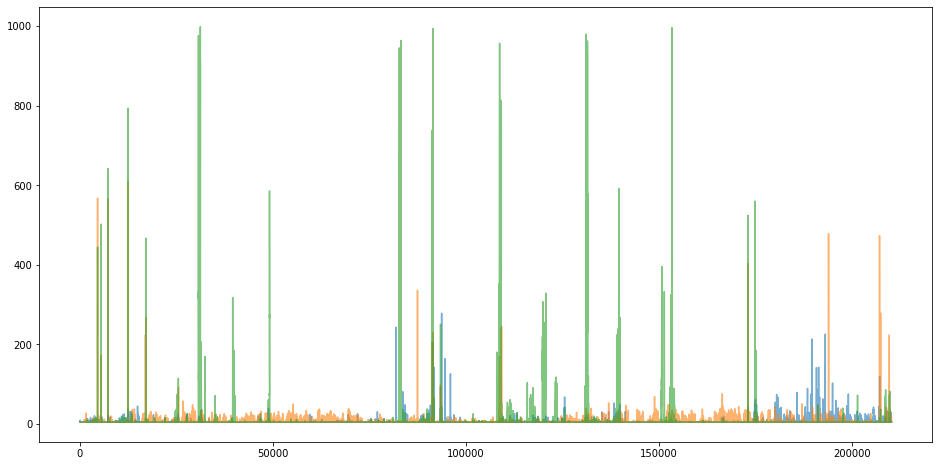

```python
plt.figure(figsize=(16,8))
plt.plot(cms_uv[['SO2_UV1','SO2_UV2','SO2_UV3']], alpha=0.6)
```

**SO2 baseline looks fine, and also looks to have a few extreme events scattered throughout. The UV3 station (green line) is near a shipping dock, and ships are known to emit high levels of SO2 when they dock and undock.**

**One important note is that this data is in 5-minute intervals, but all other data that we are working with is hourly. To reduce this dataset from 5-minute to hourly resolution and to retain as much information as possible, create features for the average, maximum, and variance within each hour:**

**Note that wind speed is tricky to take the max of, since the sign (positive/negative) depends on the direction. Since we want maximum wind speed to represent the maximum magnitude, first take the absolute value of all wind speed columns before taking the hourly maximum:**

```python
cms_uv_ws_abs = cms_uv.copy()
ws_cols = [col for col in cms_uv.columns if col.startswith('WS')]
for col in ws_cols:
    cms_uv_ws_abs[col] = cms_uv_ws_abs[col].apply(lambda x:abs(x))
cms_uv_hourly_avg = cms_uv.groupby(['YEAR','MONTH','DAY','HOUR']).mean().reset_index()
cms_uv_hourly_max = cms_uv_ws_abs.groupby(['YEAR','MONTH','DAY','HOUR']).max().reset_index()
cms_uv_hourly_var = cms_uv.groupby(['YEAR','MONTH','DAY','HOUR']).var().reset_index()
cms_uv_hourly_avg = cms_uv_hourly_avg.drop(columns=['MINUTE'])
cms_uv_hourly_max = cms_uv_hourly_max.drop(columns=['MINUTE','ACTUALDATE'])
cms_uv_hourly_var = cms_uv_hourly_var.drop(columns=['MINUTE'])
cms_uv_hourly_avg.columns = np.where(cms_uv_hourly_avg.columns.isin(['YEAR','MONTH','DAY','HOUR']),cms_uv_hourly_avg.columns,cms_uv_hourly_avg.columns+'_AVG')
cms_uv_hourly_max.columns = np.where(cms_uv_hourly_max.columns.isin(['YEAR','MONTH','DAY','HOUR']),cms_uv_hourly_max.columns,cms_uv_hourly_max.columns+'_MAX')
cms_uv_hourly_var.columns = np.where(cms_uv_hourly_var.columns.isin(['YEAR','MONTH','DAY','HOUR']),cms_uv_hourly_var.columns,cms_uv_hourly_var.columns+'_VAR')
```

```python
print(cms_uv_hourly_avg.shape)
print(cms_uv_hourly_max.shape)
print(cms_uv_hourly_var.shape)
```

```
(17522, 33)
(17522, 33)
(17522, 33)
```

**There are 22 missing hours (17522 out of 17544, we can address later after merging the entire dataframe with the other datasets (they will show up as NaN in the merged dataframe).**

**Now that the CMS and UV monitoring data is cleaned up, let's move on to the ground level monitors (GLM). Similar to the CMS and UV data, this data was read in via private API and saved as a pickle file beforehand. The GLMs only measure SO2.**

```python
glm = pd.read_pickle("data/glm.pkl")
```

```python
glm.head()
```

|  | DATETIME | SO2_GLM1 | SO2_GLM2 | SO2_GLM3 | SO2_GLM4 |
| --- | --- | --- | --- | --- | --- |
| 0 | 2014-08-01 00:00:00 | 2.075130 | 2.000188 | 2.07 | 2.097947 |
| 1 | 2014-08-01 01:00:00 | 2.075035 | 2.000190 | 2.05 | 2.017587 |
| 2 | 2014-08-01 02:00:00 | 2.074940 | 2.000191 | 2.05 | NaN |
| 3 | 2014-08-01 03:00:00 | 2.074845 | 2.000192 | 2.05 | NaN |
| 4 | 2014-08-01 04:00:00 | 2.074750 | 2.000193 | 2.03 | 2.117227 |

**This dataset has SO2 measurements at 4 different GLMs from August 2014 through the end of 2017. We only need 2016-2017. First parse out individual columns for year, month, day, and hour. Also parse out a column for Julian day, which will be used as part of a feature later to capture any seasonal variabilities.**

```python
glm['YEAR'] = glm['DATETIME'].dt.year
glm['MONTH'] = glm['DATETIME'].dt.month
glm['DAY'] = glm['DATETIME'].dt.day
glm['HOUR'] = glm['DATETIME'].dt.hour
glm['JDAY'] = glm['DATETIME'].dt.strftime('%j')
glm['JDAY'] = pd.to_numeric(glm['JDAY'])
glm = glm[glm.YEAR.isin([2016,2017])].reset_index(drop=True)
```

```python
glm.head()
```

|  | DATETIME | SO2_GLM1 | SO2_GLM2 | SO2_GLM3 | SO2_GLM4 | YEAR | MONTH | DAY | HOUR | JDAY |
| --- | --- | --- | --- | --- | --- | --- | --- | --- | --- | --- |
| 0 | 2016-01-01 00:00:00 | 2.029718 | 2.453649 | 2.08 | 2.882102 | 2016 | 1 | 1 | 0 | 1 |
| 1 | 2016-01-01 01:00:00 | 2.029718 | 2.113647 | 2.08 | 2.872089 | 2016 | 1 | 1 | 1 | 1 |
| 2 | 2016-01-01 02:00:00 | 2.029717 | 2.693645 | 2.55 | 2.772075 | 2016 | 1 | 1 | 2 | 1 |
| 3 | 2016-01-01 03:00:00 | 2.029717 | 2.683642 | 2.08 | NaN | 2016 | 1 | 1 | 3 | 1 |
| 4 | 2016-01-01 04:00:00 | 2.029716 | 2.403640 | 2.17 | NaN | 2016 | 1 | 1 | 4 | 1 |

```python
glm.shape[0]
```

```
17544
```

**Numerical EDA:**

```python
glm.describe().transpose()
```

|  | count | mean | std | min | 25% | 50% | 75% | max |
| --- | --- | --- | --- | --- | --- | --- | --- | --- |
| SO2_GLM1 | 17540.0 | 2.186078 | 0.671586 | 1.907210 | 2.018162 | 2.032419 | 2.040086 | 23.944674 |
| SO2_GLM2 | 17536.0 | 2.162811 | 0.280651 | 1.784398 | 2.012270 | 2.054859 | 2.164590 | 7.825737 |
| SO2_GLM3 | 17541.0 | 4.670802 | 5.047291 | 2.080000 | 2.720000 | 3.180000 | 3.860000 | 89.320000 |
| SO2_GLM4 | 16232.0 | 2.528146 | 0.603284 | 1.572591 | 2.182365 | 2.352229 | 2.654192 | 14.106505 |
| YEAR | 17544.0 | 2016.499316 | 0.500014 | 2016.000000 | 2016.000000 | 2016.000000 | 2017.000000 | 2017.000000 |
| MONTH | 17544.0 | 6.519836 | 3.449649 | 1.000000 | 4.000000 | 7.000000 | 10.000000 | 12.000000 |
| DAY | 17544.0 | 15.738714 | 8.804172 | 1.000000 | 8.000000 | 16.000000 | 23.000000 | 31.000000 |
| HOUR | 17544.0 | 11.500000 | 6.922384 | 0.000000 | 5.750000 | 11.500000 | 17.250000 | 23.000000 |
| JDAY | 17544.0 | 183.250342 | 105.513966 | 1.000000 | 92.000000 | 183.000000 | 275.000000 | 366.000000 |

**Looking at missing values:**

```python
glm.isnull().sum()
```

```
DATETIME       0
SO2_GLM1       4
SO2_GLM2       8
SO2_GLM3       3
SO2_GLM4    1312
YEAR           0
MONTH          0
DAY            0
HOUR           0
JDAY           0
dtype: int64
```

**GLMs 1, 2 and 3 only have a few missing values throughout, so interpolation is likely the best method to use here. But GLM4 is missing more values. Are these scattered throughout (where interpolation would be acceptable to fill in missing gaps), or was there a long period of missing data?**

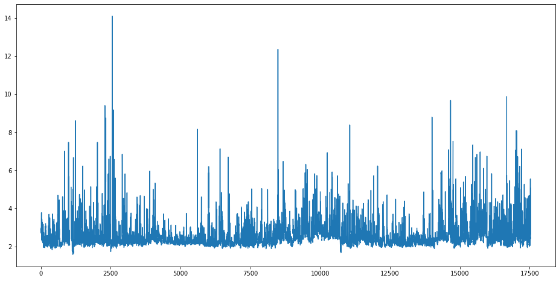

```python
plt.figure(figsize=(16,8))
plt.plot(glm.SO2_GLM4)
```

**There doesn't seem to be a long stretch of missing data, so let's just impute using interpolation:**

```python
glm_cols = [col for col in glm.columns if "GLM" in col]
for col in glm_cols:
    glm[col] = glm[col].interpolate()
glm.isnull().sum()
```

```
DATETIME    0
SO2_GLM1    0
SO2_GLM2    0
SO2_GLM3    0
SO2_GLM4    0
YEAR        0
MONTH       0
DAY         0
HOUR        0
JDAY        0
dtype: int64
```

**No NaNs remaining, now look at the distributions of each of the GLM measurements:**

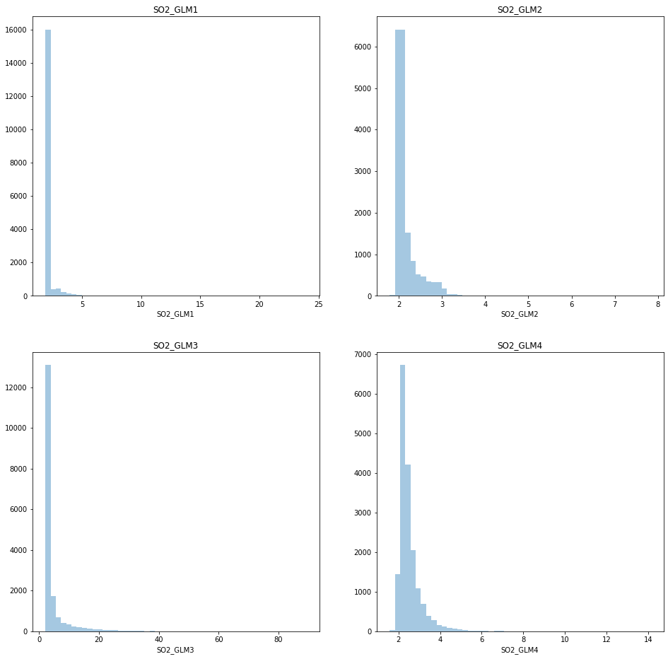

```python
distplots(glm, glm_cols, ncol_plot=2)
```

**We have very positively skewed features again, but this should not be surprising for air quality monitoring data. How does the percent completeness look? The detection limit for the GLMs is 2 ppb.**

```python
for col in glm_cols:
    pct_complete = glm.loc[glm[col] > 2].shape[0]/glm.shape[0]
    print(col + ": " + str(round(pct_complete*100,1)) + "% complete")
```

```
SO2_GLM1: 93.5% complete
SO2_GLM2: 91.3% complete
SO2_GLM3: 100.0% complete
SO2_GLM4: 97.6% complete
```

**High level of completeness for all 4 monitors is a good sign, compared to the low level of completeness for the UV fenceline monitors. This is likely because there are a lot of measurements in between 2-5 ppb, which is the range that the GLMs can detect but the UV fenceline cannot.**

**Now let's see if there is any correlation between the different GLMs:**

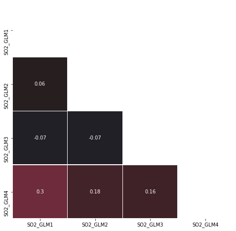

```python
corr_matrix(glm, glm_cols, figsize=(8,8))
```

**The monitors' measurements don't appear to be well correlated, which suggests that they are located far apart from each other and are likely measuring different sources of SO2.**

**How do the timeseries look, any need for baseline adjustment?**

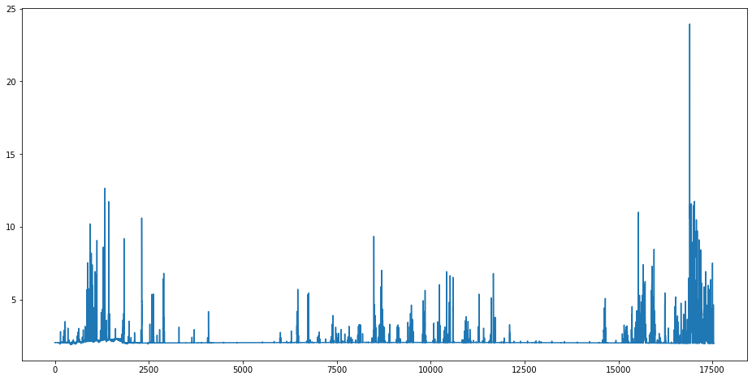

```python
plt.figure(figsize=(16,8))
plt.plot(glm.SO2_GLM1)
```

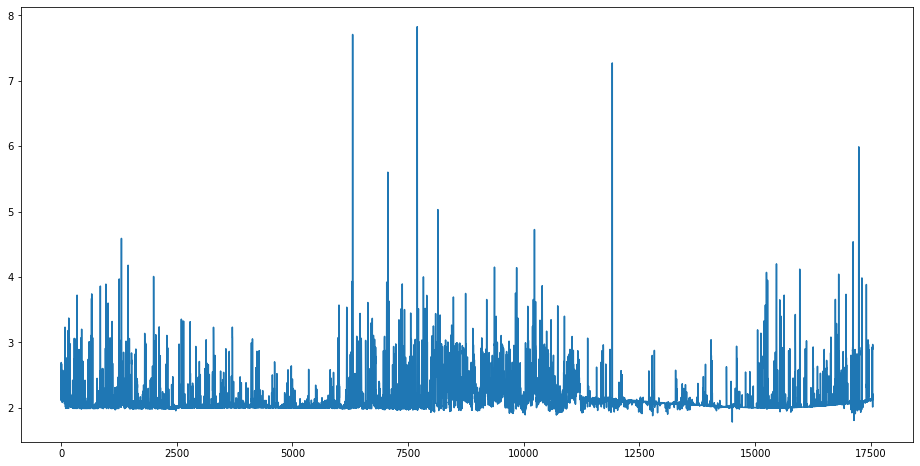

```python
plt.figure(figsize=(16,8))
plt.plot(glm.SO2_GLM2)
```

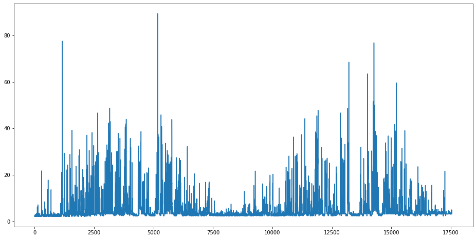

```python
plt.figure(figsize=(16,8))
plt.plot(glm.SO2_GLM3)
```

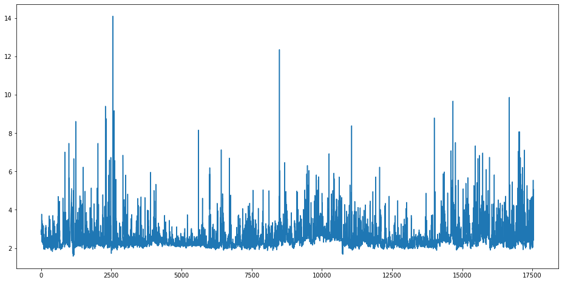

```python
plt.figure(figsize=(16,8))
plt.plot(glm.SO2_GLM4)
```

**Relative to the range of readings, the baseline looks more or less steady (i.e. no consistent upward or downward drift) and does not need any adjustment.**

**Our last set of data is from the Bay Area Air Quality Management District stations, which can be downloaded from EPA's API. The URL is edited for a specific pollutant code (in this case, SO2), station ID, and state ID.**

```python
def load_aqs_json(year, site_id):
    json_url = 'https://aqs.epa.gov/data/api/sampleData/bySite?email=test@aqs.api&key=test&param=42401&bdate='+str(year)+'0101&edate='+str(year)+'1231&state=06&county=013&site='+site_id
    with urllib.request.urlopen(json_url) as url:
        aqs_json = json.loads(url.read().decode())
    return pd.DataFrame.from_dict(aqs_json['Data'])
```

**Read in data for two stations (AQS1 and AQS2), and store in dataframes for 2016 and 2017:**

```python
aqs1_2016 = load_aqs_json(2016, '0006')
aqs1_2017 = load_aqs_json(2017, '0006')
aqs2_2016 = load_aqs_json(2016, '1004')
aqs2_2017 = load_aqs_json(2017, '1004')
```

**Look at the shapes of the dataframes to make sure every hour has a reading:**

```python
print(aqs1_2016.shape)
print(aqs1_2017.shape)
print(aqs2_2016.shape)
print(aqs2_2017.shape)
```

```
(8784, 27)
(8760, 27)
(8784, 27)
(8760, 27)
```

**Concatenate dataframes into one large dataframe for both 2016 and 2017:**

```python
aqs1_df = pd.concat([aqs1_2016, aqs1_2017], ignore_index=True)
aqs2_df = pd.concat([aqs2_2016, aqs2_2017], ignore_index=True)
```

```python
aqs1_df.head()
```

|  | state_code | county_code | site_number | parameter_code | poc | latitude | longitude | datum | parameter | date_local | time_local | date_gmt | time_gmt | sample_measurement | units_of_measure | sample_duration | sample_frequency | detection_limit | uncertainty | qualifier | method_type | method_code | method | state | county | date_of_last_change | cbsa_code |
| --- | --- | --- | --- | --- | --- | --- | --- | --- | --- | --- | --- | --- | --- | --- | --- | --- | --- | --- | --- | --- | --- | --- | --- | --- | --- | --- | --- |
| 0 | 06 | 013 | 0006 | 42401 | 1 | 37.948172 | -122.364852 | WGS84 | Sulfur dioxide | 2016-12-31 | 23:00 | 2017-01-01 | 07:00 | 0.7 | Parts per billion | 1 HOUR | HOURLY | 2.0 | None | None | FEM | 060 | INSTRUMENTAL - PULSED FLUORESCENT | California | Contra Costa | 2017-02-16 | 41860 |
| 1 | 06 | 013 | 0006 | 42401 | 1 | 37.948172 | -122.364852 | WGS84 | Sulfur dioxide | 2016-12-31 | 22:00 | 2017-01-01 | 06:00 | 0.7 | Parts per billion | 1 HOUR | HOURLY | 2.0 | None | None | FEM | 060 | INSTRUMENTAL - PULSED FLUORESCENT | California | Contra Costa | 2017-02-16 | 41860 |
| 2 | 06 | 013 | 0006 | 42401 | 1 | 37.948172 | -122.364852 | WGS84 | Sulfur dioxide | 2016-12-31 | 21:00 | 2017-01-01 | 05:00 | 0.8 | Parts per billion | 1 HOUR | HOURLY | 2.0 | None | None | FEM | 060 | INSTRUMENTAL - PULSED FLUORESCENT | California | Contra Costa | 2017-02-16 | 41860 |
| 3 | 06 | 013 | 0006 | 42401 | 1 | 37.948172 | -122.364852 | WGS84 | Sulfur dioxide | 2016-12-31 | 20:00 | 2017-01-01 | 04:00 | 0.8 | Parts per billion | 1 HOUR | HOURLY | 2.0 | None | None | FEM | 060 | INSTRUMENTAL - PULSED FLUORESCENT | California | Contra Costa | 2017-02-16 | 41860 |
| 4 | 06 | 013 | 0006 | 42401 | 1 | 37.948172 | -122.364852 | WGS84 | Sulfur dioxide | 2016-12-31 | 19:00 | 2017-01-01 | 03:00 | 0.6 | Parts per billion | 1 HOUR | HOURLY | 2.0 | None | None | FEM | 060 | INSTRUMENTAL - PULSED FLUORESCENT | California | Contra Costa | 2017-02-16 | 41860 |

**Extract only the useful columns (datetime, measurement values), and convert datetime into a compatible format:**

```python
aqs1 = aqs1_df.copy()[['date_local','time_local','sample_measurement']]
aqs2 = aqs2_df.copy()[['date_local','time_local','sample_measurement']]
aqs1['DATETIME'] = aqs1.apply(lambda x:dt.datetime.strptime(x.date_local+" "+x.time_local, '%Y-%m-%d %H:%M'), axis=1)
aqs2['DATETIME'] = aqs2.apply(lambda x:dt.datetime.strptime(x.date_local+" "+x.time_local, '%Y-%m-%d %H:%M'), axis=1)
aqs1 = aqs1[['DATETIME','sample_measurement']]
aqs2 = aqs2[['DATETIME','sample_measurement']]
aqs1 = aqs1.rename(columns={'sample_measurement':'SO2_AQS1'})
aqs2 = aqs2.rename(columns={'sample_measurement':'SO2_AQS2'})
```

**Check for NaNs:**

```python
aqs1.isnull().sum()
```

```
DATETIME       0
SO2_AQS1    1690
dtype: int64
```

```python
aqs2.isnull().sum()
```

```
DATETIME       0
SO2_AQS2    1311
dtype: int64
```

**How do the timeseries look? Is it ok to interpolate to fill NaNs?**

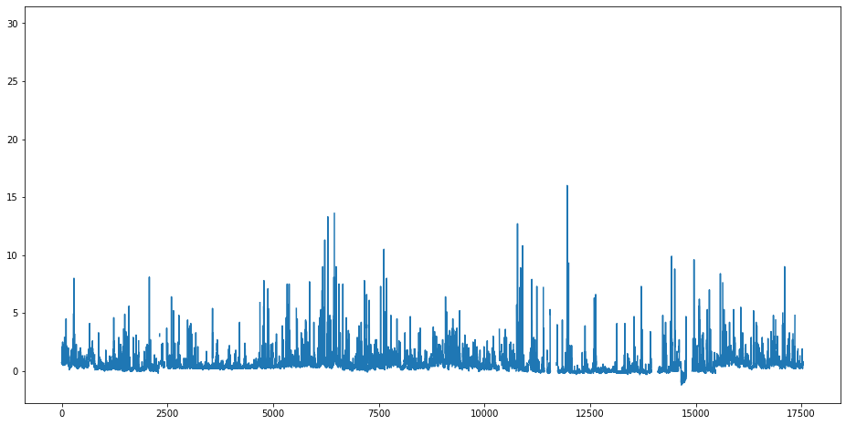

```python
plt.figure(figsize=(16,8))
plt.plot(aqs1.SO2_AQS1)
```

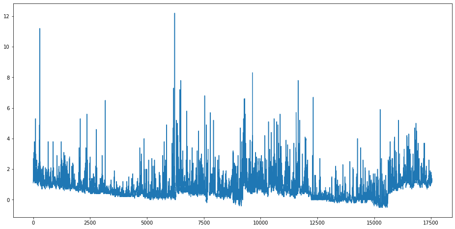

```python
plt.figure(figsize=(16,8))
plt.plot(aqs2.SO2_AQS2)
```

**It seems ok to interpolate, but this dataset will need some baseline adjustment. First interpolate to fill NaNs:**

```python
aqs1 = aqs1.interpolate()
aqs2 = aqs2.interpolate()
```

**Peakutils has a function to estimate the baseline of a data interval, which is represented by an n-degree polynomial (the value of n is an input to the function). Use this to create a function for baseline adjustment:**

- **Inputs to the function are the full dataframe needing baseline adjustment, the timesplits that represent the start and end of a single baseline drift, and the baseline value (e.g. detection limit).**
- **One timesplit interval is needed for each segment where the baseline drifts differently. For example if the baseline drifts upwards and then downwards, two separate timesplits would be needed for baseline adjustment. The peakutils baseline function estimates an n-degree polynomial to represent the drifting baseline for each segment.**

```python
import peakutils
def baseline_corr(df, col, timesplits, base=0.5):
    '''Performs baseline correction on a certain column (col) in a dataframe (df).
       Correction done using a 2-degree polynomial baseline fit for each timesplit defined by the user.'''
    n=0
    Y_new = []
    X_new = []
    df = df.reset_index()
    for start,stop in timesplits:
        n += 1
        start = start
        stop = stop
        if n == len(timesplits):
            time_mask = (df['DATETIME'] <= stop) & (df['DATETIME'] >= start)
        else:
            time_mask = (df['DATETIME'] < stop) & (df['DATETIME'] >= start)
        X = df[(time_mask)]['DATETIME'].values
        Y = df[(time_mask)][col].values

        # Correction baseline is the fitted baseline minus the baseline value
        df_base = peakutils.baseline(Y,2) - base

        # segY is the measurement with corrected baseline
        segX = X
        segY = Y - df_base
        Y_new.extend(segY)
        X_new.extend(segX)

    # create new dataframe
    df_new = pd.DataFrame({'DATETIME':X_new , col: Y_new})
    df_new = df_new.set_index('DATETIME')
    return df_new
```

```python
timestart = pd.to_datetime("2016-01-01 00:00")
timeend1 = pd.to_datetime("2016-03-30 13:00")
timeend2 = pd.to_datetime("2016-09-27 20:00")
timeend3 = pd.to_datetime("2016-11-29 06:00")
timeend4 = pd.to_datetime("2017-03-28 18:00")
timeend5 = pd.to_datetime("2017-04-20 10:00")
timeend6 = pd.to_datetime("2017-05-01 09:00")
timeend7 = pd.to_datetime("2017-12-04 21:00")
timeend8 = pd.to_datetime("2017-12-31 23:00")
timesplits_aqs1 = np.array([[timestart, timeend1], [timeend1, timeend2], [timeend2, timeend3], [timeend3, timeend4], [timeend4, timeend5], [timeend5, timeend6], [timeend6, timeend7], [timeend7, timeend8]])
```

```python
aqs1_corr = baseline_corr(aqs1, 'SO2_AQS1', timesplits_aqs1)
aqs1_corr = aqs1_corr.sort_index()
```

**Now look at the corrected baseline:**

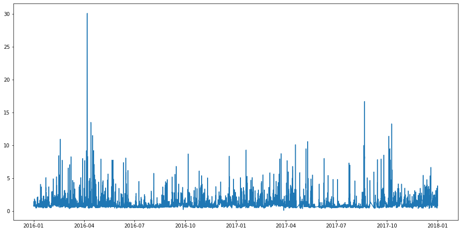

```python
plt.figure(figsize=(16,8))
plt.plot(aqs1_corr.SO2_AQS1)
```

**Looks a lot more reasonable now. AQS2 will require some more work and more timestamps:**

```python
timestart = pd.to_datetime("2016-01-01 00:00")
timeend1 = pd.to_datetime("2016-02-16 08:00")
timeend2 = pd.to_datetime("2016-02-20 11:00")
timeend3 = pd.to_datetime("2016-03-22 02:00")
timeend4 = pd.to_datetime("2016-04-14 07:00")
timeend5 = pd.to_datetime("2016-06-13 14:00")
timeend6 = pd.to_datetime("2016-12-31 23:00")
timeend7 = pd.to_datetime("2017-03-22 13:00")
timeend8 = pd.to_datetime("2017-04-22 05:00")
timeend9 = pd.to_datetime("2017-08-10 05:00")
timeend10 = pd.to_datetime("2017-09-08 12:00")
timeend11 = pd.to_datetime("2017-10-27 21:00")
timeend12 = pd.to_datetime("2017-12-13 15:00")
timeend13 = pd.to_datetime("2017-12-31 23:00")

timesplits_aqs2 = np.array([[timestart, timeend1], [timeend1, timeend2], [timeend2, timeend3], [timeend3, timeend4], [timeend4, timeend5],[timeend5, timeend6],[timeend6, timeend7],[timeend7, timeend8],[timeend8, timeend9],[timeend9, timeend10],[timeend10, timeend11],[timeend11, timeend12],[timeend12, timeend13]])
```

```python
aqs2_corr = baseline_corr(aqs2, 'SO2_AQS2', timesplits_aqs2)
aqs2_corr = aqs2_corr.sort_index()
```

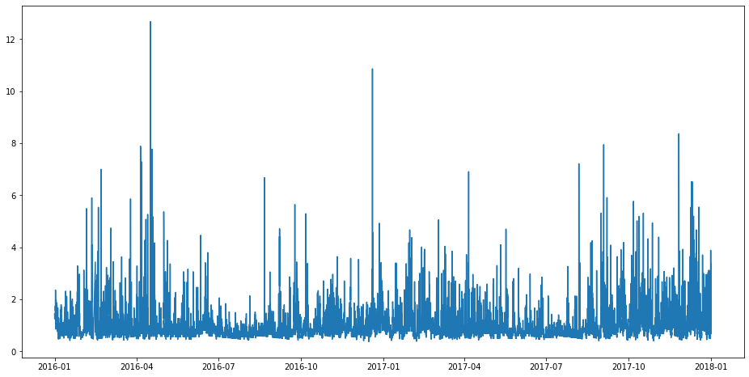

```python
plt.figure(figsize=(16,8))
plt.plot(aqs2_corr.SO2_AQS2)
```

**Now that the baselines are fixed, merge the two AQS dataframes on datetime:**

```python
aqs_merge = aqs1_corr.merge(aqs2_corr, on='DATETIME', how='outer')
```

**Parse out datetime:**

```python
aqs = aqs_merge.reset_index()
aqs['YEAR'] = aqs['DATETIME'].apply(lambda x:x.year)
aqs['MONTH'] = aqs['DATETIME'].apply(lambda x:x.month)
aqs['DAY'] = aqs['DATETIME'].apply(lambda x:x.day)
aqs['HOUR'] = aqs['DATETIME'].apply(lambda x:x.hour)
aqs['HOUR'] = aqs['HOUR']
aqs = aqs.drop(columns=['DATETIME'])
```

```python
aqs.head()
```

|  | SO2_AQS1 | SO2_AQS2 | YEAR | MONTH | DAY | HOUR |
| --- | --- | --- | --- | --- | --- | --- |
| 0 | 1.217580 | 1.207989 | 2016 | 12 | 31 | 23 |
| 1 | 1.217562 | 0.802644 | 2016 | 12 | 31 | 22 |
| 2 | 1.317544 | 1.002846 | 2016 | 12 | 31 | 21 |
| 3 | 1.317526 | 1.003048 | 2016 | 12 | 31 | 20 |
| 4 | 1.117508 | 1.003250 | 2016 | 12 | 31 | 19 |

```python
aqs.shape
```

```
(17544, 6)
```

**Now we have 5 separate dataframes with monitoring data, merge all of them on date/time for a single monitoring data DF:**

```python
glm = glm.drop(columns=['DATETIME'])
monitor_df = cms_uv_hourly_avg.copy()
monitor_df = monitor_df.merge(cms_uv_hourly_max, on=['YEAR','MONTH','DAY','HOUR'], how='outer')
monitor_df = monitor_df.merge(cms_uv_hourly_var, on=['YEAR','MONTH','DAY','HOUR'], how='outer')
monitor_df = monitor_df.merge(glm, on=['YEAR','MONTH','DAY','HOUR'], how='outer')
monitor_df = monitor_df.merge(aqs, on=['YEAR','MONTH','DAY','HOUR'], how='outer')
```

```python
monitor_df.shape
```

```
(17544, 98)
```

```python
monitor_df.head()
```

|  | YEAR | MONTH | DAY | HOUR | NH3_CMS1_AVG | H2S_CMS1_AVG | BC_CMS1_AVG | PM25_CMS1_AVG | NH3_CMS2_AVG | H2S_CMS2_AVG | BC_CMS2_AVG | PM25_CMS2_AVG | NH3_CMS3_AVG | H2S_CMS3_AVG | BC_CMS3_AVG | PM25_CMS3_AVG | SO2_UV1_AVG | SO2_UV2_AVG | SO2_UV3_AVG | WS_X_CMS1_AVG | WS_Y_CMS1_AVG | WS_X_CMS2_AVG | WS_Y_CMS2_AVG | WS_X_CMS3_AVG | WS_Y_CMS3_AVG | WS_X_UV1_AVG | WS_Y_UV1_AVG | WS_X_UV2_AVG | WS_Y_UV2_AVG | … |
| --- | --- | --- | --- | --- | --- | --- | --- | --- | --- | --- | --- | --- | --- | --- | --- | --- | --- | --- | --- | --- | --- | --- | --- | --- | --- | --- | --- | --- | --- | --- |
| 0 | 2016 | 1.0 | 1 | 0.0 | 4.868333 | 1.259167 | 4.900750 | 41.0 | 9.064167 | 1.0 | 2.787333 | 18.0 | 4.105000 | 1.261667 | 3.666250 | 26.0 | 5.0 | 5.0 | 5.0 | 1.298252 | -5.742205 | -0.858508 | -1.730956 | 0.165849 | 0.168075 | -1.028100 | -3.129355 | -2.097166 | -1.473645 | … |
| 1 | 2016 | 1.0 | 1 | 1.0 | 4.765000 | 1.087500 | 2.748500 | 27.0 | 8.534167 | 1.0 | 2.206917 | 30.0 | 4.156667 | 1.000000 | 3.675083 | 27.0 | 5.0 | 5.0 | 5.0 | 3.207973 | -6.308830 | -0.219728 | -1.328900 | 0.002908 | 0.083283 | -0.188390 | -3.796677 | -0.506721 | -2.032053 | … |
| 2 | 2016 | 1.0 | 1 | 2.0 | 6.033333 | 1.816667 | 3.496250 | 25.0 | 11.589167 | 1.0 | 2.391417 | 24.0 | 3.680000 | 1.000000 | 2.009667 | 20.0 | 5.0 | 5.0 | 5.0 | 1.398677 | -1.894589 | -0.497117 | -0.663436 | 0.000000 | 0.000000 | -1.153081 | -1.231468 | -0.819376 | -0.347127 | … |
| 3 | 2016 | 1.0 | 1 | 3.0 | 3.443333 | 1.524167 | 3.674083 | 21.0 | 8.965000 | 1.0 | 1.342167 | 25.0 | 3.158333 | 1.000000 | 1.997833 | 14.0 | 5.0 | 5.0 | 5.0 | -2.101173 | -7.432369 | -1.514275 | -1.506292 | 0.000000 | 0.000000 | -2.542529 | -4.296541 | -2.543722 | -1.274732 | … |
| 4 | 2016 | 1.0 | 1 | 4.0 | 4.056667 | 1.000000 | 1.682000 | 26.0 | 7.291667 | 1.0 | 0.810333 | 11.0 | 3.055000 | 1.000000 | 1.812917 | 11.0 | 5.0 | 5.0 | 5.0 | -3.015036 | -7.283977 | -2.058740 | -1.775681 | 0.000000 | 0.000000 | -2.365091 | -2.412874 | -4.252358 | -0.717530 | … |

**Look at NAs:**

```python
monitor_df.isnull().sum()
```

```
YEAR              0
MONTH             0
DAY               0
HOUR              0
NH3_CMS1_AVG     22
H2S_CMS1_AVG     22
BC_CMS1_AVG      22
PM25_CMS1_AVG    22
NH3_CMS2_AVG     22
H2S_CMS2_AVG     22
BC_CMS2_AVG      22
PM25_CMS2_AVG    22
NH3_CMS3_AVG     22
H2S_CMS3_AVG     22
BC_CMS3_AVG      22
PM25_CMS3_AVG    22
SO2_UV1_AVG      22
SO2_UV2_AVG      22
SO2_UV3_AVG      22
WS_X_CMS1_AVG    22
WS_Y_CMS1_AVG    22
WS_X_CMS2_AVG    22
WS_Y_CMS2_AVG    22
WS_X_CMS3_AVG    22
WS_Y_CMS3_AVG    22
WS_X_UV1_AVG     22
WS_Y_UV1_AVG     22
WS_X_UV2_AVG     22
WS_Y_UV2_AVG     22
WS_X_UV3_AVG     22
WS_Y_UV3_AVG     22
TEMP_AVG         22
RH_AVG           22
NH3_CMS1_MAX     22
H2S_CMS1_MAX     22
BC_CMS1_MAX      22
PM25_CMS1_MAX    22
NH3_CMS2_MAX     22
H2S_CMS2_MAX     22
BC_CMS2_MAX      22
```

[output cut: 44 more lines]

```
WS_Y_UV1_VAR     23
WS_X_UV2_VAR     23
WS_Y_UV2_VAR     23
WS_X_UV3_VAR     23
WS_Y_UV3_VAR     23
TEMP_VAR         23
RH_VAR           23
SO2_GLM1          0
SO2_GLM2          0
SO2_GLM3          0
SO2_GLM4          0
JDAY              0
SO2_AQS1          0
SO2_AQS2          0
dtype: int64
```

**It would make the most sense to interpolate for the averages. First sort the dataframe on HOUR/DAY/MONTH, then interpolate. Use plots to make sure the date has been sorted correctly:**

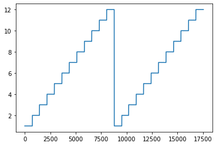

```python
monitor_df = monitor_df.sort_values(by=['YEAR','MONTH','DAY','HOUR']).reset_index(drop=True)
plt.plot(monitor_df.MONTH)
```

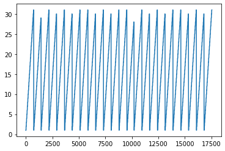

```python
plt.plot(monitor_df.DAY)
```

```python
avg_cols = [col for col in monitor_df.columns if col.endswith("AVG")]
max_cols = [col for col in monitor_df.columns if col.endswith("MAX")]
for col in avg_cols:
    monitor_df[col] = monitor_df[col].interpolate()
for col in max_cols:
    monitor_df[col] = monitor_df[col].interpolate()
```

**Replace NA in the VAR columns with zeros - this also indicates that the AVG for these columns were filled in with interpolation, or that the VAR is actually zero since there was just one sample:**

```python
var_cols = [col for col in monitor_df.columns if col.endswith("VAR")]
for col in var_cols:
    monitor_df[col] = monitor_df[col].fillna(0)
```

```python
monitor_df.isnull().sum()
```

```
YEAR             0
MONTH            0
DAY              0
HOUR             0
NH3_CMS1_AVG     0
H2S_CMS1_AVG     0
BC_CMS1_AVG      0
PM25_CMS1_AVG    0
NH3_CMS2_AVG     0
H2S_CMS2_AVG     0
BC_CMS2_AVG      0
PM25_CMS2_AVG    0
NH3_CMS3_AVG     0
H2S_CMS3_AVG     0
BC_CMS3_AVG      0
PM25_CMS3_AVG    0
SO2_UV1_AVG      0
SO2_UV2_AVG      0
SO2_UV3_AVG      0
WS_X_CMS1_AVG    0
WS_Y_CMS1_AVG    0
WS_X_CMS2_AVG    0
WS_Y_CMS2_AVG    0
WS_X_CMS3_AVG    0
WS_Y_CMS3_AVG    0
WS_X_UV1_AVG     0
WS_Y_UV1_AVG     0
WS_X_UV2_AVG     0
WS_Y_UV2_AVG     0
WS_X_UV3_AVG     0
WS_Y_UV3_AVG     0
TEMP_AVG         0
RH_AVG           0
NH3_CMS1_MAX     0
H2S_CMS1_MAX     0
BC_CMS1_MAX      0
PM25_CMS1_MAX    0
NH3_CMS2_MAX     0
H2S_CMS2_MAX     0
BC_CMS2_MAX      0
```

[output cut: 44 more lines]

```
WS_Y_UV1_VAR     0
WS_X_UV2_VAR     0
WS_Y_UV2_VAR     0
WS_X_UV3_VAR     0
WS_Y_UV3_VAR     0
TEMP_VAR         0
RH_VAR           0
SO2_GLM1         0
SO2_GLM2         0
SO2_GLM3         0
SO2_GLM4         0
JDAY             0
SO2_AQS1         0
SO2_AQS2         0
dtype: int64
```

[figure not shown]

```python
avg_var_max_cols = [col for col in monitor_df.columns if (col.endswith("VAR") or col.endswith("AVG") or col.endswith("MAX"))]
distplots(monitor_df, avg_var_max_cols)
```

**Skewness may be an issue with many of the variables that needs to be addressed later - especially for variance, lots of the values end up being close to 0.**

## Meteorological Data (precip, solar radiation, cloud cover, ceiling height)

**Meteorological data has an important effect on air pollutant concentrations. Precipitation typically washes pollution out of the atmosphere, while more cloud cover and a lower ceiling height decreases the mixing volume, which increases the pollutant concentrations.**

```python
precip = pd.read_csv("data/Precip_Richmond.csv")
cloud = pd.read_csv("data/OAK_Airport_NCDC.csv")
solar = pd.read_csv("data/Solar_Richmond.csv")
```

### Precipitation data

**First look at precip data, parse out datetime string:**

```python
precip = precip.rename(columns={'DATE / TIMEPST':'DT', 'RAINTIP INCHES':'RAINTIP'})
precip.head()
```

|  | DT | RAINTIP |
| --- | --- | --- |
| 0 | 01/01/2016 00:00 | 7.41 |
| 1 | 01/01/2016 01:00 | 7.41 |
| 2 | 01/01/2016 02:00 | 7.41 |
| 3 | 01/01/2016 03:00 | 7.41 |
| 4 | 01/01/2016 04:00 | 7.41 |

```python
precip['MONTH'] = precip['DT'].str[:2].astype(int)
precip['DAY'] = precip['DT'].str[3:5].astype(int)
precip['YEAR'] = precip['DT'].str[6:10].astype(int)
precip['HOUR'] = precip['DT'].str[11:13].astype(int)
precip = precip.drop(columns='DT')
```

```python
precip.head()
```

|  | RAINTIP | MONTH | DAY | YEAR | HOUR |
| --- | --- | --- | --- | --- | --- |
| 0 | 7.41 | 1 | 1 | 2016 | 0 |
| 1 | 7.41 | 1 | 1 | 2016 | 1 |
| 2 | 7.41 | 1 | 1 | 2016 | 2 |
| 3 | 7.41 | 1 | 1 | 2016 | 3 |
| 4 | 7.41 | 1 | 1 | 2016 | 4 |

**Hourly precip is equal to the difference in raintip between two hours:**

```python
precip['PRECIP'] = precip['RAINTIP'].diff().fillna(0)
```

```python
precip.head()
```

|  | RAINTIP | MONTH | DAY | YEAR | HOUR | PRECIP |
| --- | --- | --- | --- | --- | --- | --- |
| 0 | 7.41 | 1 | 1 | 2016 | 0 | 0.0 |
| 1 | 7.41 | 1 | 1 | 2016 | 1 | 0.0 |
| 2 | 7.41 | 1 | 1 | 2016 | 2 | 0.0 |
| 3 | 7.41 | 1 | 1 | 2016 | 3 | 0.0 |
| 4 | 7.41 | 1 | 1 | 2016 | 4 | 0.0 |

**Something weird is going on, it looks like the raintip reset to 0 in the middle of the year. Just set this inflection point to 0, as if the raintip didn't change. The between hour difference should remain the same throughout.**

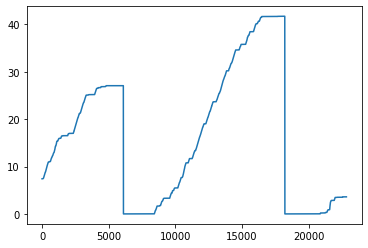

```python
plt.plot(precip.RAINTIP)
```

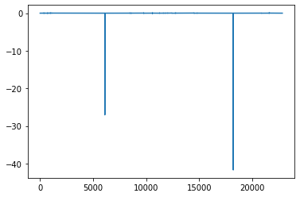

```python
plt.plot(precip.PRECIP)
```

```python
precip['PRECIP'] = precip['PRECIP'].apply(lambda x:0 if x < 0 else x)
```

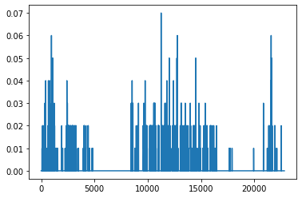

```python
plt.plot(precip.PRECIP)
```

**This is a typical trend for annual precipitation - the wet season is in fall/winter, and the dry season is in summer.**

**Looks more reasonable now, drop the RAINTIP column and finalize the precip dataset:**

```python
precip = precip.drop(columns='RAINTIP')
precip.head()
```

|  | MONTH | DAY | YEAR | HOUR | PRECIP |
| --- | --- | --- | --- | --- | --- |
| 0 | 1 | 1 | 2016 | 0 | 0.0 |
| 1 | 1 | 1 | 2016 | 1 | 0.0 |
| 2 | 1 | 1 | 2016 | 2 | 0.0 |
| 3 | 1 | 1 | 2016 | 3 | 0.0 |
| 4 | 1 | 1 | 2016 | 4 | 0.0 |

```python
precip.shape
```

```
(22825, 5)
```

**There are some hours with multiple data points, since we are measuring the difference in raintip it's appropriate to just groupby and sum over individual hours.**

```python
precip = precip.groupby(['MONTH','DAY','YEAR','HOUR']).sum().reset_index()
precip.shape
```

```
(17214, 5)
```

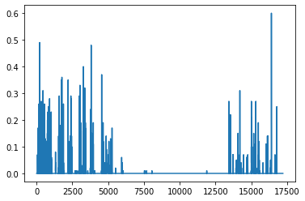

```python
plt.plot(precip.PRECIP)
```

**There are now hours with missing values, but we can merge on another dataframe later and fill in the NA with zeros.**

### Solar data

**Dates are already parsed, so only thing here is to determine which measure of solar irradiance to use. GHI is most representative of actual solar radiation reaching the surface.**

```python
solar.head()
```

|  | Year | Month | Day | Hour | Minute | DHI | DNI | GHI |
| --- | --- | --- | --- | --- | --- | --- | --- | --- |
| 0 | 2016 | 1 | 1 | 0 | 30 | 0 | 0 | 0 |
| 1 | 2016 | 1 | 1 | 1 | 30 | 0 | 0 | 0 |
| 2 | 2016 | 1 | 1 | 2 | 30 | 0 | 0 | 0 |
| 3 | 2016 | 1 | 1 | 3 | 30 | 0 | 0 | 0 |
| 4 | 2016 | 1 | 1 | 4 | 30 | 0 | 0 | 0 |

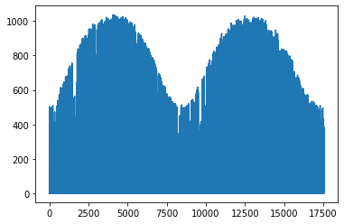

```python
plt.plot(solar.GHI)
```

**This plot confirms the seasonality we should see with solar data.**

```python
solar = solar.drop(columns=['Minute','DHI','DNI'])
solar.head()
```

|  | Year | Month | Day | Hour | GHI |
| --- | --- | --- | --- | --- | --- |
| 0 | 2016 | 1 | 1 | 0 | 0 |
| 1 | 2016 | 1 | 1 | 1 | 0 |
| 2 | 2016 | 1 | 1 | 2 | 0 |
| 3 | 2016 | 1 | 1 | 3 | 0 |
| 4 | 2016 | 1 | 1 | 4 | 0 |

```python
solar.columns = map(str.upper, solar.columns)
```

```python
solar.shape
```

```
(17544, 5)
```

### Cloud data

```python
cloud.head()
```

|  | USAF | WBAN | YR--MODAHRMN | DIR | SPD | GUS | CLG | SKC | L | M | H | VSB | MW | MW.1 | MW.2 | MW.3 | AW | AW.1 | AW.2 | AW.3 | W | TEMP | DEWP | SLP | ALT | STP | MAX | MIN | PCP01 | … |
| --- | --- | --- | --- | --- | --- | --- | --- | --- | --- | --- | --- | --- | --- | --- | --- | --- | --- | --- | --- | --- | --- | --- | --- | --- | --- | --- | --- | --- | --- | --- |
| 0 | 724930 | 23230 | 201601010053 | 360 | 7 | *** | 722 | CLR | * | * | * | 10 | ** | ** | ** | ** | ** | ** | ** | ** | * | 49 | 28 | 1021.4 | 30.16 | 1018.1 | *** | *** | 0 | … |
| 1 | 724930 | 23230 | 201601010153 | *** | 0 | *** | 722 | CLR | * | * | * | 10 | ** | ** | ** | ** | ** | ** | ** | ** | * | 47 | 27 | 1021.6 | 30.17 | 1018.4 | *** | *** | 0 | … |
| 2 | 724930 | 23230 | 201601010253 | 90 | 3 | *** | 722 | CLR | * | * | * | 10 | ** | ** | ** | ** | ** | ** | ** | ** | * | 46 | 27 | 1021.7 | 30.17 | 1018.4 | *** | *** | 0 | … |
| 3 | 724930 | 23230 | 201601010353 | *** | 0 | *** | 722 | CLR | * | * | * | 10 | ** | ** | ** | ** | ** | ** | ** | ** | * | 41 | 31 | 1021.8 | 30.18 | 1018.7 | *** | *** | 0 | … |
| 4 | 724930 | 23230 | 201601010453 | 130 | 7 | *** | 722 | CLR | * | * | * | 10 | ** | ** | ** | ** | ** | ** | ** | ** | * | 42 | 30 | 1021.6 | 30.17 | 1018.4 | *** | *** | 0 | … |

**Keep only the columns that matter:**

- **Datetime (need to reformat)**
- **CLG (cloud ceiling height in hundreds of feet, 722 = unlimited)**
- **SKC (cloud cover, CLR = clear; SCT = scattered, 1/8 to 4/8; BKN = broken, 5/8 to 7/8; OVC = overcast; OBS = obscured; POB = partial obscuration)**
- **STP (station pressure)**

```python
cloud = cloud[['YR--MODAHRMN','CLG','SKC','STP']].rename(columns={'YR--MODAHRMN':'DT'})
cloud.head()
```

|  | DT | CLG | SKC | STP |
| --- | --- | --- | --- | --- |
| 0 | 201601010053 | 722 | CLR | 1018.1 |
| 1 | 201601010153 | 722 | CLR | 1018.4 |
| 2 | 201601010253 | 722 | CLR | 1018.4 |
| 3 | 201601010353 | 722 | CLR | 1018.7 |
| 4 | 201601010453 | 722 | CLR | 1018.4 |

```python
cloud = cloud.replace('***',np.nan)
cloud = cloud.replace('******',np.nan)
```

**Parse out dates:**

```python
cloud['DT'] = cloud['DT'].astype(str)
cloud['YEAR'] = cloud['DT'].str[:4].astype(int)
cloud['MONTH'] = cloud['DT'].str[4:6].astype(int)
cloud['DAY'] = cloud['DT'].str[6:8].astype(int)
cloud['HOUR'] = cloud['DT'].str[8:10].astype(int)
cloud.head()
```

|  | DT | CLG | SKC | STP | YEAR | MONTH | DAY | HOUR |
| --- | --- | --- | --- | --- | --- | --- | --- | --- |
| 0 | 201601010053 | 722 | CLR | 1018.1 | 2016 | 1 | 1 | 0 |
| 1 | 201601010153 | 722 | CLR | 1018.4 | 2016 | 1 | 1 | 1 |
| 2 | 201601010253 | 722 | CLR | 1018.4 | 2016 | 1 | 1 | 2 |
| 3 | 201601010353 | 722 | CLR | 1018.7 | 2016 | 1 | 1 | 3 |
| 4 | 201601010453 | 722 | CLR | 1018.4 | 2016 | 1 | 1 | 4 |

```python
cloud = cloud.drop(columns='DT')
cloud.shape
```

```
(21427, 7)
```

**Looks like there are hours with multiple samples here too. Let's take care of missing values first. For CLG, just interpolate:**

```python
cloud.isnull().sum()
```

```
CLG        732
SKC      11678
STP        784
YEAR         0
MONTH        0
DAY          0
HOUR         0
dtype: int64
```

```python
cloud.dtypes
```

```
CLG      object
SKC      object
STP      object
YEAR      int32
MONTH     int32
DAY       int32
HOUR      int32
dtype: object
```

```python
cloud['CLG'] = cloud['CLG'].astype(float)
cloud['STP'] = cloud['STP'].astype(float)
cloud = cloud.interpolate()
cloud.isnull().sum()
```

```
CLG          0
SKC      11678
STP          0
YEAR         0
MONTH        0
DAY          0
HOUR         0
dtype: int64
```

**Looking more closely at SKC, how does CLG look where the NaNs occur?**

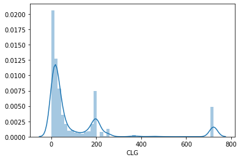

```python
sns.distplot(cloud.loc[cloud.SKC.isna()]['CLG'])
```

**Difficult to determine when to replace values with BKN or OVR, not completely apparent based on the data we have. Come back to cloud cover or just leave it out? Ceiling height and solar radiation may be enough to piece it together.**

```python
cloud = cloud.drop(columns=['SKC'])
```

```python
cloud.shape
```

```
(21427, 6)
```

**Now take care of cases with multiple samples per hour, use groupby to average over each hour:**

```python
cloud = cloud.groupby(['YEAR','MONTH','DAY','HOUR']).mean().reset_index()
cloud.head()
```

|  | YEAR | MONTH | DAY | HOUR | CLG | STP |
| --- | --- | --- | --- | --- | --- | --- |
| 0 | 2016 | 1 | 1 | 0 | 722.0 | 1018.1 |
| 1 | 2016 | 1 | 1 | 1 | 722.0 | 1018.4 |
| 2 | 2016 | 1 | 1 | 2 | 722.0 | 1018.4 |
| 3 | 2016 | 1 | 1 | 3 | 722.0 | 1018.7 |
| 4 | 2016 | 1 | 1 | 4 | 722.0 | 1018.4 |

```python
cloud.shape
```

```
(17544, 6)
```

**Merge all met data in one single dataframe:**

```python
met_all = pd.merge(precip, solar, on=['YEAR','MONTH','DAY','HOUR'], how='outer')
met_all = pd.merge(met_all, cloud, on=['YEAR','MONTH','DAY','HOUR'], how='outer')
print(met_all.shape)
met_all.head()
```

```
(17544, 8)
```

|  | MONTH | DAY | YEAR | HOUR | PRECIP | GHI | CLG | STP |
| --- | --- | --- | --- | --- | --- | --- | --- | --- |
| 0 | 1 | 1 | 2016 | 0 | 0.0 | 0 | 722.0 | 1018.1 |
| 1 | 1 | 1 | 2016 | 1 | 0.0 | 0 | 722.0 | 1018.4 |
| 2 | 1 | 1 | 2016 | 2 | 0.0 | 0 | 722.0 | 1018.4 |
| 3 | 1 | 1 | 2016 | 3 | 0.0 | 0 | 722.0 | 1018.7 |
| 4 | 1 | 1 | 2016 | 4 | 0.0 | 0 | 722.0 | 1018.4 |

```python
met_all.isnull().sum()
```

```
MONTH       0
DAY         0
YEAR        0
HOUR        0
PRECIP    330
GHI         0
CLG         0
STP         0
dtype: int64
```

**Fill in missing precip values with zeros:**

```python
met_all['PRECIP'] = met_all['PRECIP'].fillna(0)
```

```python
met_all.isnull().sum()
```

```
MONTH     0
DAY       0
YEAR      0
HOUR      0
PRECIP    0
GHI       0
CLG       0
STP       0
dtype: int64
```

```python
met_all = met_all.rename(columns={'GHI':'SOLAR_GHI','CLG':'CEIL_HT'})
```

**We finally have all the data needed to train the models, but they are all in three separate dataframes. Merge all three into one:**

```python
df_aermod.head()
```

|  | DATE | S1_UV1_1 | S1_UV1_10 | S1_UV1_11 | S1_UV1_12 | S1_UV1_13 | S1_UV1_14 | S1_UV1_15 | S1_UV1_16 | S1_UV1_17 | S1_UV1_18 | S1_UV1_19 | S1_UV1_2 | S1_UV1_20 | S1_UV1_21 | S1_UV1_3 | S1_UV1_4 | S1_UV1_5 | S1_UV1_6 | S1_UV1_7 | S1_UV1_8 | S1_UV1_9 | S1_CMS1 | S1_GLM1 | S1_GLM2 | S1_GLM3 | S1_CMS2 | S1_UV2_1 | S1_UV2_10 | … |
| --- | --- | --- | --- | --- | --- | --- | --- | --- | --- | --- | --- | --- | --- | --- | --- | --- | --- | --- | --- | --- | --- | --- | --- | --- | --- | --- | --- | --- | --- | --- |
| 0 | 16010101 | 0.0 | 0.0 | 0.0 | 0.0 | 0.0 | 0.0 | 0.0 | 0.0 | 0.0 | 0.0 | 0.0 | 0.0 | 0.0 | 0.0 | 0.0 | 0.0 | 0.0 | 0.0 | 0.0 | 0.0 | 0.0 | 0.0 | 0.0 | 0.0 | 0.0 | 0.0 | 0.0 | 0.0 | … |
| 1 | 16010102 | 0.0 | 0.0 | 0.0 | 0.0 | 0.0 | 0.0 | 0.0 | 0.0 | 0.0 | 0.0 | 0.0 | 0.0 | 0.0 | 0.0 | 0.0 | 0.0 | 0.0 | 0.0 | 0.0 | 0.0 | 0.0 | 0.0 | 0.0 | 0.0 | 0.0 | 0.0 | 0.0 | 0.0 | … |
| 2 | 16010103 | 0.0 | 0.0 | 0.0 | 0.0 | 0.0 | 0.0 | 0.0 | 0.0 | 0.0 | 0.0 | 0.0 | 0.0 | 0.0 | 0.0 | 0.0 | 0.0 | 0.0 | 0.0 | 0.0 | 0.0 | 0.0 | 0.0 | 0.0 | 0.0 | 0.0 | 0.0 | 0.0 | 0.0 | … |
| 3 | 16010104 | 0.0 | 0.0 | 0.0 | 0.0 | 0.0 | 0.0 | 0.0 | 0.0 | 0.0 | 0.0 | 0.0 | 0.0 | 0.0 | 0.0 | 0.0 | 0.0 | 0.0 | 0.0 | 0.0 | 0.0 | 0.0 | 0.0 | 0.0 | 0.0 | 0.0 | 0.0 | 0.0 | 0.0 | … |
| 4 | 16010105 | 0.0 | 0.0 | 0.0 | 0.0 | 0.0 | 0.0 | 0.0 | 0.0 | 0.0 | 0.0 | 0.0 | 0.0 | 0.0 | 0.0 | 0.0 | 0.0 | 0.0 | 0.0 | 0.0 | 0.0 | 0.0 | 0.0 | 0.0 | 0.0 | 0.0 | 0.0 | 0.0 | 0.0 | … |